# **Problem Statement**

## **Business Context**

Aeolus Renewables is an independent power producer operating a fleet of 1,150 onshore wind turbines (2.5 MW class) across 16 wind farms in the central plains region, with a combined installed capacity of roughly 2.87 GW. The company sells the electricity its turbines produce to the grid under long-term power purchase agreements, where revenue is tied directly to how much energy is delivered - so every hour a turbine is offline is energy that cannot be sold. A regional operations centre monitors the fleet around the clock, supported by an O&M organisation of about 140 field technicians.

Each turbine continuously streams condition data through its SCADA (Supervisory Control and Data Acquisition) system - drivetrain vibration, bearing and oil temperatures, rotor and generator speed, and power output - recorded as 10-minute averages, the standard logging resolution for utility-scale turbines. The exact channels vary by turbine type, but together they describe the health of the main subassemblies in near-real time. Today, maintenance runs on a mix of fixed-interval inspections and reactive repair: technicians follow a scheduled service calendar, and the control room responds when an automated alarm trips or a turbine faults offline.

The most consequential components are in the drivetrain - the gearbox and main bearing - which are expensive, slow to procure, and require a mobile crane to replace. The gearbox alone represents approximately 13% of the overall capital cost of an onshore turbine, and within gearboxes the failures are dominated by bearings: one widely-cited breakdown puts the split at bearings (70%), gears (26%) and other causes (4%). The core problem is recognition. By the time a drivetrain fault has developed far enough to matter, its signature is real but still tangled in normal operating noise across many channels - and the existing fixed thresholds only trip once the fault is near-catastrophic, when the turbine is already offline or the component has seized. A genuinely fault drivetrain can run for hours or days looking "normal" to a threshold alarm, while a control-room analyst has no practical way to tell it apart from a healthy machine reacting to gusty wind. The consequences:

- Each unplanned drivetrain failure takes a turbine offline for an estimated 7–21 days, directly forfeiting saleable energy under the power purchase agreement.
- Emergency crane mobilisation and expedited parts run at a steep premium over the same work scheduled in advance, making an unplanned gearbox replacement a major cost event.
- A degrading main bearing left running frequently destroys the gearbox it feeds, converting a contained repair into a far larger one.
- Control-room analysts manually scan a flood of channels across 1,150 turbines, and alarm fatigue means genuine degradation signals slip through unnoticed until the machine faults offline.

## **Objective**

This proof of concept builds a drivetrain-condition classifier that reads each turbine's live sensor signature and labels the drivetrain as "fault" or "normal", serving operations-centre analysts and maintenance planners. The solution

- Reads each turbine's multi-channel sensor signature and produces a clear fault-vs-normal signal, so analysts can concentrate on the handful of machines genuinely in a fault condition rather than scanning the whole fleet.
- Distinguishes a truly fault drivetrain from normal operating noise more reliably than fixed thresholds, catching faults that are present but not yet severe enough to trip a catastrophic alarm - the window in which a turbine can still be stopped before a bearing fault cascades into gearbox destruction. Is deliberately tuned to favour catching true failures over avoiding false alerts, because a missed fault drivetrain costs far more than an unnecessary inspection.
- Establishes a measurable detection baseline on historical fleet data, so the capability's accuracy and its operational value can be judged on evidence before any wider rollout.

Once proven at proof-of-concept scale, this capability would give Aeolus a defensible basis to move drivetrain maintenance from reactive repair toward condition-based intervention - reducing unplanned downtime, protecting saleable energy revenue, and containing repairs before they escalate across a 1150-turbine fleet.

## **Data Dictionary**

The dataset, `wind_turbine_detection.csv` contains 10-minute SCADA records for 15 turbines.

### Identifiers & Metadata

| Column | Data Type | Description |
| --- | --- | --- |
| timestamp | datetime | Date and time of the 10-minute logging interval; establishes chronological sequence. |
| turbine_id | object (categorical) | Unique code identifying individual wind turbines; used to track specific asset history. |

### Environmental Conditions

| Column | Data Type | Description |
| --- | --- | --- |
| rated_power_kW | float | Maximum engineered power capacity of the turbine; defines its performance baseline. |
| wind_speed_mps | float | Velocity of the incoming wind; the primary driver of kinetic energy input. |
| wind_direction_deg | float | Compass direction of oncoming wind; used to assess turbine alignment. |
| turbulence_intensity | float | Measure of wind speed fluctuation; higher intensity increases structural fatigue. |
| air_density_kgm3 | float | Mass of air per unit volume; directly impacts aerodynamic lift and power potential. |
| ambient_temp_C | float | Outdoor air temperature surrounding the turbine; affects cooling efficiency. |
| humidity_pct | float | Relative moisture level in the air; flags risks for electrical insulation degradation or corrosion. |

### Operational Control & State

| Column | Data Type | Description |
| --- | --- | --- |
| power_output_kW | float | Real-time electricity generated; drops or fluctuations can signal mechanical drag. |
| rotor_speed_rpm | float | Rotational speed of the main blades; reflects low-speed shaft dynamics. |
| generator_speed_rpm | float | Rotational speed of the generator shaft; crucial for detecting gearbox slip. |
| blade_pitch_angle_deg | float | Angle of the blades relative to the wind; adjusted to control power and rotor speed. |
| yaw_misalignment_deg | float | Angle deviation between wind direction and nacelle orientation; high values cause uneven drivetrain stress. |

### Thermal Metrics (Component Health)

| Column | Data Type | Description |
| --- | --- | --- |
| gearbox_oil_temp_C | float | Temperature of the lubricating oil; spikes indicate excessive mechanical friction. |
| gearbox_bearing_temp_C | float | Internal temperature of gearbox bearings; a leading indicator of bearing wear. |
| generator_bearing_temp_C | float | Temperature of generator bearings; flags alignment or lubrication issues. |
| generator_winding_temp_C | float | Temperature of internal electrical coils; spikes indicate electrical overload or cooling failure. |
| main_bearing_temp_C | float | Temperature of the primary low-speed shaft bearing; handles massive structural loads. |
| nacelle_temp_C | float | Air temperature inside the enclosed housing; reflects global internal heat dissipation. |

### Vibration & Diagnostics (FFT)

| Column | Data Type | Description |
| --- | --- | --- |
| drivetrain_vibration_rms_mmps | float | Overall energy of drivetrain vibrations; general indicator of mechanical roughness. |
| tower_vibration_mmps | float | Structural oscillation of the turbine tower; flags aerodynamic or rotor imbalance. |
| vib_fft_bearing_bpfo | float | Vibration amplitude at the bearing outer-race defect frequency; tracks outer-ring pitting. |
| vib_fft_bearing_bpfi | float | Vibration amplitude at the bearing inner-race defect frequency; tracks inner-ring pitting. |
| vib_fft_gearmesh | float | Vibration amplitude at the teeth-meshing frequency; isolates gearbox tooth wear or misalignment. |
| vib_fft_sideband | float | Vibration amplitude surrounding main frequencies; flags localized faults like cracked gear teeth. |

### Lubrication & Particle Analysis

| Column | Data Type | Description |
| --- | --- | --- |
| oil_particle_count | float | Quantity of metallic debris suspended in lubricating oil; direct indicator of component wear. |
| oil_pressure_bar | float | Pressure of the lubrication system; drops indicate leaks, pump failures, or oil thinning. |

### Asset Lifecycle & History

| Column | Data Type | Description |
| --- | --- | --- |
| operating_hours_total | float | Cumulative runtime of the turbine; represents the asset's total mechanical mileage. |
| cumulative_energy_MWh | float | Total historical electricity produced; measures the lifetime work done by the drivetrain. |
| load_cycles | int | Total count of fatigue-inducing stress variations; correlates directly with structural aging. |
| hours_since_last_maintenance | float | Time elapsed since last service; crucial for identifying maintenance-cycle fatigue. |
| prior_fault_count | int | Total historical fault events triggered; highlights chronic or poorly repaired issues. |
| component_age_days | float | Elapsed lifetime of active components; captures chronological wear independent of runtime. |

### Targets (Labels)

| Column | Data Type | Description |
| --- | --- | --- |
| failure | int (0/1) | The target variable; boolean flag indicating if the drivetrain or turbine is healthy (0) or failing (1). |

# **Installing and Importing the Necessary Libraries**

```python
%pip install pandas==2.2.2 numpy==2.0.2 scikit-learn==1.6.1 tensorflow==2.20.0 keras==3.13.2 xgboost==3.2.0 seaborn==0.13.2 matplotlib==3.10.0 -q
```

**Note**:

- After running the above cell, kindly restart the notebook kernel (for VS Code) or runtime (for Google Colab), and run all cells sequentially from the next cell.
- On executing the above line of code, you might see a warning regarding package dependencies. This message can be ignored as the above code ensures that all necessary libraries and their dependencies are maintained to successfully execute the code in **this notebook**.

```python
# Standard libraries for tracking execution time and vector/matrix operations
import time
import numpy as np

# Data manipulation and visualization libraries
import pandas as pd
import matplotlib.pyplot as plt
import seaborn as sns

# Tree-based and ensemble machine learning classifiers
from sklearn.tree import DecisionTreeClassifier
from sklearn.ensemble import RandomForestClassifier, GradientBoostingClassifier
from xgboost import XGBClassifier

# Utilities for handling class imbalance, model evaluation, and metric calculations
from sklearn.utils.class_weight import compute_class_weight
from sklearn.metrics import (accuracy_score, recall_score, precision_score, f1_score,
                             confusion_matrix, ConfusionMatrixDisplay)

# Deep learning framework and specific layers for building Artificial Neural Networks (ANNs)
import tensorflow as tf
from keras.models import Sequential  # Model for building NN sequentially.
from keras.layers import Dense, Dropout, BatchNormalization

# Preprocessing tools for scaling data and tools for model optimization/explainability
from sklearn.preprocessing import StandardScaler
from sklearn.model_selection import RandomizedSearchCV  # To tune different models
from sklearn.inspection import permutation_importance

# Configuration settings to suppress warnings and format data display outputs
import warnings
warnings.filterwarnings('ignore')              # Suppress warnings for cleaner output logs
sns.set_style('whitegrid')                     # Set a consistent clean grid style for plots
pd.set_option('display.max_columns', None)     # Prevent truncation of columns when displaying dataframes
```

# **Loading the Data**

Loading "wind_turbine_detection.csv" dataset into Pandas DataFrame

```python
wind_df = pd.read_csv("data/raw/wind_turbine_detection.csv")
```

# **Data Overview**

## Viewing the first and last 5 rows of the dataset

Examine the first and last five rows of the dataset. Identify the available features, observe the values stored in each column, and become familiar with the dataset's structure.

```python
# View the first and last five rows to inspect the dataset structure and feature values

print("\nFirst 5 rows:")
display(wind_df.head())

print("\nLast 5 rows:")
display(wind_df.tail())
```

```
First 5 rows:
```

|  | timestamp | turbine_id | rated_power_kW | wind_speed_mps | wind_direction_deg | turbulence_intensity | air_density_kgm3 | ambient_temp_C | humidity_pct | power_output_kW | rotor_speed_rpm | generator_speed_rpm | blade_pitch_angle_deg | yaw_misalignment_deg | gearbox_oil_temp_C | gearbox_bearing_temp_C | generator_bearing_temp_C | generator_winding_temp_C | main_bearing_temp_C | nacelle_temp_C | drivetrain_vibration_rms_mmps | tower_vibration_mmps | vib_fft_bearing_bpfo | vib_fft_bearing_bpfi | vib_fft_gearmesh | vib_fft_sideband | oil_particle_count | oil_pressure_bar | operating_hours_total | … |
| --- | --- | --- | --- | --- | --- | --- | --- | --- | --- | --- | --- | --- | --- | --- | --- | --- | --- | --- | --- | --- | --- | --- | --- | --- | --- | --- | --- | --- | --- | --- |
| 0 | 1/1/2024 0:00 | T001 | 1500 | 2.335 | 151.993 | 0.149 | 1.205 | 21.820 | 68.717 | 0.000 | 0.000 | 14.414 | 87.761 | -5.455 | 53.728 | 56.728 | 57.637 | 61.546 | 48.728 | 29.820 | 1.518 | 0.974 | 0.455 | 0.391 | 0.455 | 0.399 | 55.756 | 6.032 | 19319.612 | … |
| 1 | 1/1/2024 0:10 | T001 | 1500 | 9.166 | 152.957 | 0.153 | 1.200 | 22.893 | 74.002 | 486.762 | 12.554 | 1134.433 | -0.159 | 0.489 | 64.105 | 67.798 | 66.841 | 85.072 | 58.544 | 33.649 | 1.480 | 0.992 | 0.455 | 0.391 | 0.455 | 0.399 | 55.756 | 5.776 | 19319.778 | … |
| 2 | 1/1/2024 0:20 | T001 | 1500 | 9.034 | 158.402 | 0.201 | 1.219 | 22.899 | 59.616 | 454.109 | 12.579 | 1143.435 | 1.061 | 4.220 | 63.868 | 66.635 | 66.093 | 82.383 | 58.365 | 32.667 | 1.753 | 1.074 | 0.455 | 0.391 | 0.455 | 0.399 | 55.756 | 5.994 | 19319.945 | … |
| 3 | 1/1/2024 0:30 | T001 | 1500 | 13.284 | 159.023 | 0.159 | 1.181 | 22.727 | 64.676 | 1446.811 | 16.941 | 1526.358 | 5.718 | 1.584 | 83.654 | 89.761 | 85.749 | 128.484 | 77.257 | 36.349 | 1.924 | 1.379 | 0.455 | 0.391 | 0.455 | 0.399 | 55.756 | 5.541 | 19320.112 | … |
| 4 | 1/1/2024 0:40 | T001 | 1500 | 2.239 | 159.842 | 0.189 | 1.173 | 23.742 | 65.423 | 0.000 | 0.194 | 27.405 | 88.452 | 3.400 | 54.573 | 57.150 | 56.817 | 60.963 | 51.506 | 32.234 | 1.497 | 0.936 | 0.455 | 0.391 | 0.455 | 0.399 | 55.756 | 6.018 | 19320.112 | … |

```
Last 5 rows:
```

|  | timestamp | turbine_id | rated_power_kW | wind_speed_mps | wind_direction_deg | turbulence_intensity | air_density_kgm3 | ambient_temp_C | humidity_pct | power_output_kW | rotor_speed_rpm | generator_speed_rpm | blade_pitch_angle_deg | yaw_misalignment_deg | gearbox_oil_temp_C | gearbox_bearing_temp_C | generator_bearing_temp_C | generator_winding_temp_C | main_bearing_temp_C | nacelle_temp_C | drivetrain_vibration_rms_mmps | tower_vibration_mmps | vib_fft_bearing_bpfo | vib_fft_bearing_bpfi | vib_fft_gearmesh | vib_fft_sideband | oil_particle_count | oil_pressure_bar | operating_hours_total | … |
| --- | --- | --- | --- | --- | --- | --- | --- | --- | --- | --- | --- | --- | --- | --- | --- | --- | --- | --- | --- | --- | --- | --- | --- | --- | --- | --- | --- | --- | --- | --- |
| 131755 | 3/1/2024 23:10 | T015 | 3000 | 5.680 | 108.327 | 0.306 | 1.200 | 19.599 | 60.093 | 95.437 | 8.399 | 764.196 | -0.123 | -6.325 | 53.286 | 60.399 | 56.996 | 63.265 | 50.056 | 27.808 | 2.139 | 0.886 | 0.322 | 0.333 | 0.424 | 0.224 | 78.731 | 5.741 | 36147.152 | … |
| 131756 | 3/1/2024 23:20 | T015 | 3000 | 6.945 | 111.198 | 0.151 | 1.207 | 18.800 | 63.952 | 254.325 | 9.789 | 886.754 | 0.507 | 1.873 | 54.811 | 62.961 | 60.368 | 67.812 | 50.091 | 27.891 | 1.470 | 0.956 | 0.322 | 0.333 | 0.424 | 0.224 | 78.731 | 6.125 | 36147.318 | … |
| 131757 | 3/1/2024 23:30 | T015 | 3000 | 2.191 | 113.020 | 0.148 | 1.214 | 18.331 | 61.764 | 0.000 | 0.029 | 3.975 | 87.072 | 0.880 | 51.704 | 60.440 | 57.181 | 63.706 | 47.760 | 26.242 | 1.793 | 0.897 | 0.322 | 0.333 | 0.424 | 0.224 | 78.731 | 5.955 | 36147.318 | … |
| 131758 | 3/1/2024 23:40 | T015 | 3000 | 11.003 | 117.356 | 0.178 | 1.200 | 19.640 | 62.729 | 2056.378 | 14.527 | 1297.923 | 0.869 | 4.662 | 72.463 | 84.704 | 78.389 | 111.169 | 66.612 | 31.989 | 1.764 | 1.212 | 0.322 | 0.333 | 0.424 | 0.224 | 78.731 | 5.920 | 36147.485 | … |
| 131759 | 3/1/2024 23:50 | T015 | 3000 | 2.231 | 116.146 | 0.160 | 1.206 | 19.598 | 66.575 | 0.000 | 0.040 | 0.936 | 88.206 | 0.105 | 51.646 | 60.774 | 57.721 | 63.360 | 46.512 | 28.247 | 1.833 | 1.239 | 0.322 | 0.333 | 0.424 | 0.224 | 78.731 | 5.886 | 36147.485 | … |

## Checking the shape of the dataset

Identify the total number of rows and columns to understand the size of the dataset before proceeding with the analysis.

```python
# Check the dataset dimensions to understand its size

rows, columns = wind_df.shape
print(f"Dataset shape: {rows} rows, {columns} columns")
```

```
Dataset shape: 131760 rows, 35 columns
```

## Checking the attribute types

Identify the data type of each feature and determine whether it is numerical, categorical, or datetime. This helps in selecting appropriate preprocessing and analysis techniques.

```python
# Display concise summary of the DataFrame, including data types and non-null counts
wind_df.info()
```

```
<class 'pandas.core.frame.DataFrame'>
RangeIndex: 131760 entries, 0 to 131759
Data columns (total 35 columns):
 #   Column                         Non-Null Count   Dtype
---  ------                         --------------   -----
 0   timestamp                      131760 non-null  object
 1   turbine_id                     131760 non-null  object
 2   rated_power_kW                 131760 non-null  int64
 3   wind_speed_mps                 131760 non-null  float64
 4   wind_direction_deg             131760 non-null  float64
 5   turbulence_intensity           131760 non-null  float64
 6   air_density_kgm3               131760 non-null  float64
 7   ambient_temp_C                 131760 non-null  float64
 8   humidity_pct                   131760 non-null  float64
 9   power_output_kW                131760 non-null  float64
```

[output cut: 27 more lines]

## Checking the statistical summary

Examine the statistical summary of the numerical features. Observe the key statistics to understand the data distribution and identify any unusual values.

```python
#Generating descriptive statistics for dataset
wind_df.describe(include="all")
```

|  | timestamp | turbine_id | rated_power_kW | wind_speed_mps | wind_direction_deg | turbulence_intensity | air_density_kgm3 | ambient_temp_C | humidity_pct | power_output_kW | rotor_speed_rpm | generator_speed_rpm | blade_pitch_angle_deg | yaw_misalignment_deg | gearbox_oil_temp_C | gearbox_bearing_temp_C | generator_bearing_temp_C | generator_winding_temp_C | main_bearing_temp_C | nacelle_temp_C | drivetrain_vibration_rms_mmps | tower_vibration_mmps | vib_fft_bearing_bpfo | vib_fft_bearing_bpfi | vib_fft_gearmesh | vib_fft_sideband | oil_particle_count | oil_pressure_bar | operating_hours_total | … |
| --- | --- | --- | --- | --- | --- | --- | --- | --- | --- | --- | --- | --- | --- | --- | --- | --- | --- | --- | --- | --- | --- | --- | --- | --- | --- | --- | --- | --- | --- | --- |
| count | 131760 | 131760 | 131760.000000 | 131760.000000 | 131760.000000 | 131760.000000 | 131760.000000 | 131760.000000 | 131760.00000 | 131760.000000 | 131760.000000 | 131760.000000 | 131760.000000 | 131760.000000 | 131115.000000 | 131760.000000 | 131070.000000 | 131760.000000 | 131760.000000 | 131760.000000 | 131760.000000 | 131760.000000 | 131760.000000 | 131760.000000 | 131760.000000 | 131760.000000 | 131760.000000 | 131124.000000 | 131760.000000 | … |
| unique | 8784 | 15 | NaN | NaN | NaN | NaN | NaN | NaN | NaN | NaN | NaN | NaN | NaN | NaN | NaN | NaN | NaN | NaN | NaN | NaN | NaN | NaN | NaN | NaN | NaN | NaN | NaN | NaN | NaN | … |
| top | 1/1/2024 0:00 | T001 | NaN | NaN | NaN | NaN | NaN | NaN | NaN | NaN | NaN | NaN | NaN | NaN | NaN | NaN | NaN | NaN | NaN | NaN | NaN | NaN | NaN | NaN | NaN | NaN | NaN | NaN | NaN | … |
| freq | 15 | 8784 | NaN | NaN | NaN | NaN | NaN | NaN | NaN | NaN | NaN | NaN | NaN | NaN | NaN | NaN | NaN | NaN | NaN | NaN | NaN | NaN | NaN | NaN | NaN | NaN | NaN | NaN | NaN | … |
| mean | NaN | NaN | 2166.666667 | 7.649297 | 163.155270 | 0.175353 | 1.244980 | 10.011035 | 60.02331 | 633.607766 | 9.981842 | 898.629973 | 11.963269 | 0.025354 | 58.205181 | 62.713522 | 62.394198 | 78.593421 | 52.409791 | 19.791835 | 1.834684 | 1.134653 | 0.434847 | 0.421709 | 0.584660 | 0.296410 | 73.727269 | 5.888148 | 29658.355829 | … |
| std | NaN | NaN | 743.567808 | 4.066898 | 106.644769 | 0.033725 | 0.037329 | 8.999438 | 13.06734 | 869.596264 | 4.856042 | 436.640301 | 27.743365 | 3.414029 | 11.835815 | 13.312458 | 11.634394 | 25.953997 | 10.960906 | 9.254256 | 0.515269 | 0.243325 | 0.235574 | 0.198516 | 0.206181 | 0.127504 | 31.391586 | 0.239381 | 14402.539916 | … |
| min | NaN | NaN | 1500.000000 | 0.015000 | 0.000000 | 0.121000 | 1.140000 | -9.748000 | 18.90800 | 0.000000 | 0.000000 | 0.000000 | -2.000000 | -25.764000 | 35.814000 | 37.901000 | 41.375000 | 44.771000 | 30.311000 | -2.681000 | 1.216000 | 0.801000 | 0.301000 | 0.301000 | 0.403000 | 0.203000 | 50.565000 | 3.836000 | 3932.935000 | … |
| 25% | NaN | NaN | 1500.000000 | 4.627000 | 68.288750 | 0.151000 | 1.214000 | 2.178000 | 50.03800 | 17.358000 | 7.307000 | 657.569500 | 0.237000 | -2.052250 | 49.427500 | 52.784000 | 53.800000 | 59.489000 | 44.278000 | 11.982000 | 1.506000 | 0.957000 | 0.349000 | 0.349000 | 0.479000 | 0.239000 | 58.554000 | 5.776000 | 17643.338000 | … |
| 50% | NaN | NaN | 2000.000000 | 7.136500 | 150.544000 | 0.168000 | 1.245000 | 9.977000 | 59.99800 | 198.518500 | 10.197000 | 917.741000 | 0.750000 | 0.015000 | 54.307000 | 58.135000 | 58.406000 | 66.189000 | 49.042000 | 19.825500 | 1.692000 | 1.079000 | 0.388000 | 0.384000 | 0.542000 | 0.268000 | 64.653000 | 5.915000 | 31560.400000 | … |
| 75% | NaN | NaN | 3000.000000 | 10.088000 | 254.892000 | 0.191000 | 1.276000 | 17.859000 | 70.00800 | 1014.109250 | 13.596000 | 1223.733000 | 1.776000 | 2.089000 | 65.363500 | 70.858500 | 69.132000 | 92.930500 | 58.850000 | 27.515000 | 1.976000 | 1.265000 | 0.441000 | 0.438000 | 0.636000 | 0.313000 | 74.938000 | 6.039000 | 38922.749500 | … |
| max | NaN | NaN | 3600.000000 | 32.000000 | 359.995000 | 0.450000 | 1.345000 | 29.078000 | 99.69300 | 3672.000000 | 17.628000 | 1590.833000 | 90.000000 | 25.294000 | 109.988000 | 113.862000 | 111.263000 | 158.996000 | 94.146000 | 44.331000 | 5.770000 | 3.717000 | 2.577000 | 2.846000 | 2.837000 | 1.688000 | 305.105000 | 6.689000 | 56977.855000 | … |

## Checking for missing values

Check for missing values in each feature. Identify which columns contain missing values and the extent of missing data.

```python
# Checking for null values across all columns
wind_df.isnull().sum()
```

```
timestamp                          0
turbine_id                         0
rated_power_kW                     0
wind_speed_mps                     0
wind_direction_deg                 0
turbulence_intensity               0
air_density_kgm3                   0
ambient_temp_C                     0
humidity_pct                       0
power_output_kW                    0
rotor_speed_rpm                    0
generator_speed_rpm                0
blade_pitch_angle_deg              0
yaw_misalignment_deg               0
gearbox_oil_temp_C               645
gearbox_bearing_temp_C             0
generator_bearing_temp_C         690
generator_winding_temp_C           0
main_bearing_temp_C                0
nacelle_temp_C                     0
drivetrain_vibration_rms_mmps      0
tower_vibration_mmps               0
vib_fft_bearing_bpfo               0
vib_fft_bearing_bpfi               0
vib_fft_gearmesh                   0
vib_fft_sideband                   0
oil_particle_count                 0
oil_pressure_bar                 636
operating_hours_total              0
cumulative_energy_MWh              0
load_cycles                        0
hours_since_last_maintenance       0
prior_fault_count                  0
component_age_days                 0
failure                            0
dtype: int64
```

**Missing Values Summary**

Found the missing values in:

- **`gearbox_oil_temp_C`**: 645 missing entries
- **`generator_bearing_temp_C`**: 690 missing entries
- **`oil_pressure_bar`**: 636 missing entries

All other columns have no missing values.

## Checking for duplicate values

Check for duplicate records in the dataset. Identify whether any duplicate rows are present before proceeding with the analysis.

```python
# Checking for duplicate rows
wind_df.duplicated().sum()
```

```
np.int64(0)
```

**Duplicate Records Check**

Duplicate rows present: 0

The dataset contains no duplicate records.

# **Data Preprocessing**

- Convert the timestamp column to a datetime format. This enables time-based analysis and feature engineering.
- Extract the day of the week from the timestamp. This helps capture weekly patterns in the data.
- Extract the hour from the timestamp. This helps capture hourly patterns in the data.

```python
# Create a copy of the dataset for preprocessing
wind_df_preprocessed = wind_df.copy()

# Convert timestamp to datetime
wind_df_preprocessed['timestamp'] = pd.to_datetime(wind_df_preprocessed['timestamp'])

# Extract day of week and hour from timestamp
wind_df_preprocessed['day_of_week'] = wind_df_preprocessed['timestamp'].dt.day_name()
wind_df_preprocessed['hour'] = wind_df_preprocessed['timestamp'].dt.hour

# Display the final dataset with new features
display(wind_df_preprocessed.head())
```

|  | timestamp | turbine_id | rated_power_kW | wind_speed_mps | wind_direction_deg | turbulence_intensity | air_density_kgm3 | ambient_temp_C | humidity_pct | power_output_kW | rotor_speed_rpm | generator_speed_rpm | blade_pitch_angle_deg | yaw_misalignment_deg | gearbox_oil_temp_C | gearbox_bearing_temp_C | generator_bearing_temp_C | generator_winding_temp_C | main_bearing_temp_C | nacelle_temp_C | drivetrain_vibration_rms_mmps | tower_vibration_mmps | vib_fft_bearing_bpfo | vib_fft_bearing_bpfi | vib_fft_gearmesh | vib_fft_sideband | oil_particle_count | oil_pressure_bar | operating_hours_total | … |
| --- | --- | --- | --- | --- | --- | --- | --- | --- | --- | --- | --- | --- | --- | --- | --- | --- | --- | --- | --- | --- | --- | --- | --- | --- | --- | --- | --- | --- | --- | --- |
| 0 | 2024-01-01 00:00:00 | T001 | 1500 | 2.335 | 151.993 | 0.149 | 1.205 | 21.820 | 68.717 | 0.000 | 0.000 | 14.414 | 87.761 | -5.455 | 53.728 | 56.728 | 57.637 | 61.546 | 48.728 | 29.820 | 1.518 | 0.974 | 0.455 | 0.391 | 0.455 | 0.399 | 55.756 | 6.032 | 19319.612 | … |
| 1 | 2024-01-01 00:10:00 | T001 | 1500 | 9.166 | 152.957 | 0.153 | 1.200 | 22.893 | 74.002 | 486.762 | 12.554 | 1134.433 | -0.159 | 0.489 | 64.105 | 67.798 | 66.841 | 85.072 | 58.544 | 33.649 | 1.480 | 0.992 | 0.455 | 0.391 | 0.455 | 0.399 | 55.756 | 5.776 | 19319.778 | … |
| 2 | 2024-01-01 00:20:00 | T001 | 1500 | 9.034 | 158.402 | 0.201 | 1.219 | 22.899 | 59.616 | 454.109 | 12.579 | 1143.435 | 1.061 | 4.220 | 63.868 | 66.635 | 66.093 | 82.383 | 58.365 | 32.667 | 1.753 | 1.074 | 0.455 | 0.391 | 0.455 | 0.399 | 55.756 | 5.994 | 19319.945 | … |
| 3 | 2024-01-01 00:30:00 | T001 | 1500 | 13.284 | 159.023 | 0.159 | 1.181 | 22.727 | 64.676 | 1446.811 | 16.941 | 1526.358 | 5.718 | 1.584 | 83.654 | 89.761 | 85.749 | 128.484 | 77.257 | 36.349 | 1.924 | 1.379 | 0.455 | 0.391 | 0.455 | 0.399 | 55.756 | 5.541 | 19320.112 | … |
| 4 | 2024-01-01 00:40:00 | T001 | 1500 | 2.239 | 159.842 | 0.189 | 1.173 | 23.742 | 65.423 | 0.000 | 0.194 | 27.405 | 88.452 | 3.400 | 54.573 | 57.150 | 56.817 | 60.963 | 51.506 | 32.234 | 1.497 | 0.936 | 0.455 | 0.391 | 0.455 | 0.399 | 55.756 | 6.018 | 19320.112 | … |

# **Exploratory Data Analysis**

## Utility Functions

```python
def histogram(data_df, col, title='Histogram', xlabel=None, ylabel='Frequency'):
    plt.figure(figsize=(9, 3.6))
    sns.histplot(data_df[col], bins=50, kde=True)
    plt.title(title)
    plt.xlabel(xlabel if xlabel else col)
    plt.ylabel(ylabel)
    plt.tight_layout()
    plt.show()

def barchart(data_df, x_col, y_col=None, title='Bar Chart', xlabel=None, ylabel=None, rot_degrees=30):
    plt.figure(figsize=(10, 6))
    if y_col: # Bivariate bar chart (x vs y)
        sns.barplot(x=x_col, y=y_col, data=data_df)
    else: # Univariate count plot
        order = data_df[x_col].value_counts().index
        sns.countplot(data=data_df, x=x_col, order=order)

    plt.title(title)
    plt.xlabel(xlabel if xlabel else x_col)
    plt.ylabel(ylabel if ylabel else ('Count' if not y_col else y_col))
    plt.xticks(rotation=rot_degrees, ha='right')
    plt.grid(axis='y', linestyle='--', alpha=0.7)
    plt.tight_layout()
    plt.show()

def boxplot(data_df, x_col, y_col, title='Box Plot', xlabel=None, ylabel=None):
    plt.figure(figsize=(6, 3.8))
    sns.boxplot(data=data_df, x=x_col, y=y_col)
    plt.title(title)
    plt.xlabel(xlabel if xlabel else x_col)
    plt.ylabel(ylabel if ylabel else y_col)
    plt.tight_layout()
    plt.show()

def scatterplot(data_df, x_col, y_col, title='Scatter Plot', xlabel=None, ylabel=None):
    plt.figure(figsize=(6, 3.8))
    sns.scatterplot(data=data_df, x=x_col, y=y_col)
    plt.title(title)
    plt.xlabel(xlabel if xlabel else x_col)
    plt.ylabel(ylabel if ylabel else y_col)
    plt.tight_layout()
    plt.show()
```

## Univariate Analysis

### `failure`

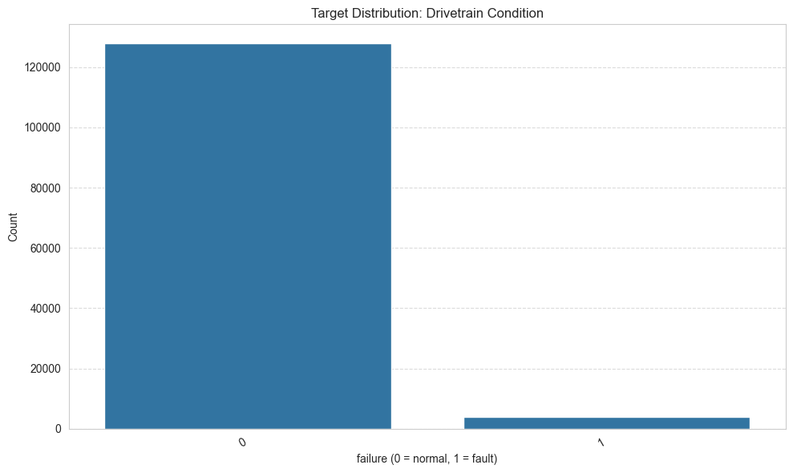

```python
barchart(wind_df_preprocessed, 'failure', title='Target Distribution: Drivetrain Condition', xlabel='failure (0 = normal, 1 = fault)')
```

**Observations**

- **Imbalanced:** about **3% failure / 97.0% non-failure** .
- Failures are rare (~3%).

### `wind_speed_mps`

Generate a histogram of the `wind_speed_mps` feature. Identify the range where most observations are concentrated and check for any skewness or unusual values.

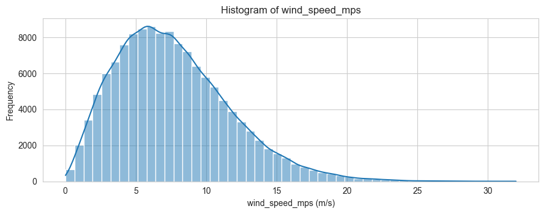

```
Count (non-null): 131760
Mean: 7.649, Median: 7.136, Std: 4.067
Q1: 4.627, Q3: 10.088, IQR: 5.461
Min: 0.015, Max: 32.0
```

```python
# Histogram and summary for `wind_speed_mps`
histogram(wind_df_preprocessed, 'wind_speed_mps', title='Histogram of wind_speed_mps', xlabel='wind_speed_mps (m/s)')

# Print concise numerical summary
s = wind_df_preprocessed['wind_speed_mps'].dropna()
print(f"Count (non-null): {s.shape[0]}")
print(f"Mean: {s.mean():.3f}, Median: {s.median():.3f}, Std: {s.std():.3f}")
print(f"Q1: {s.quantile(0.25):.3f}, Q3: {s.quantile(0.75):.3f}, IQR: {s.quantile(0.75)-s.quantile(0.25):.3f}")
print(f"Min: {s.min()}, Max: {s.max()}")
```

**Observations**

- Shape: positively skewed (long right tail). The modal region is around ~5–7 m/s.
- Range: min ≈ 0.02 m/s, max = 32.0 m/s. Very high speeds (>>20 m/s) are rare — treat as outliers or extreme-weather cases.
- Implications: turbine operation is concentrated in moderate winds.

### `air_density_kgm3`

Generate a histogram of the `air_density_kgm3` feature. Observe where most air density values are concentrated, assess the spread of the data, and identify any skewness or unusual values.

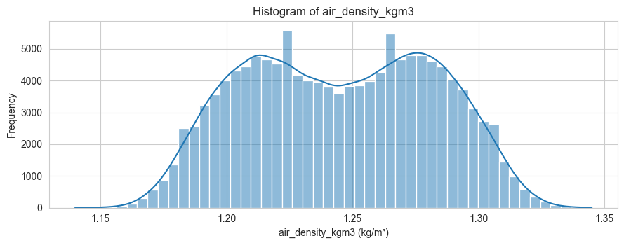

```
Count (non-null): 131760
Mean: 1.245, Median: 1.245, Std: 0.037
Q1: 1.214, Q3: 1.276, IQR: 0.062
Min: 1.14, Max: 1.345
```

```python
# Histogram and summary for `air_density_kgm3`
histogram(wind_df_preprocessed, 'air_density_kgm3', title='Histogram of air_density_kgm3', xlabel='air_density_kgm3 (kg/m³)')

# Print concise numerical summary
s = wind_df_preprocessed['air_density_kgm3'].dropna()
print(f"Count (non-null): {s.shape[0]}")
print(f"Mean: {s.mean():.3f}, Median: {s.median():.3f}, Std: {s.std():.3f}")
print(f"Q1: {s.quantile(0.25):.3f}, Q3: {s.quantile(0.75):.3f}, IQR: {s.quantile(0.75)-s.quantile(0.25):.3f}")
print(f"Min: {s.min()}, Max: {s.max()}")
```

**Observations**

- Central tendency: mean ≈ 1.2450 kg/m³; median ≈ 1.2450 kg/m³.
- Range: min = 1.14, max = 1.345 — values are tightly clustered (narrow physical range).
- Interpretation: air density varies only slightly across the dataset.

### `gearbox_oil_temp_C`

Generate a histogram of the `gearbox_oil_temp_C` feature. Observe where most gearbox oil temperature values are concentrated, assess the spread of the data, and identify any skewness or unusual values.

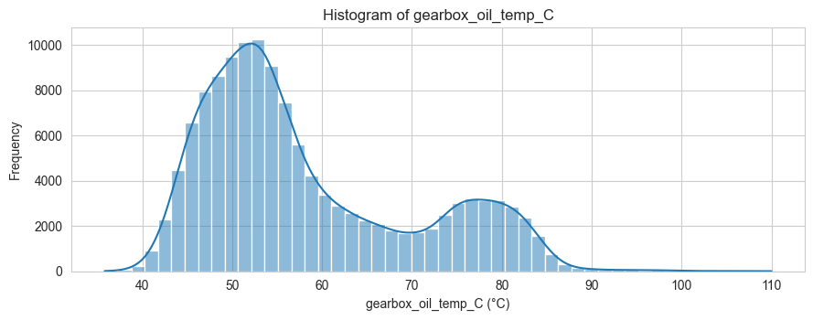

```
Count (non-null): 131115
Mean: 58.205, Median: 54.307, Std: 11.836
Q1: 49.427, Q3: 65.364, IQR: 15.936
Min: 35.814, Max: 109.988
```

```python
# Histogram and summary for `gearbox_oil_temp_C`
histogram(wind_df_preprocessed, 'gearbox_oil_temp_C', title='Histogram of gearbox_oil_temp_C', xlabel='gearbox_oil_temp_C (°C)')

# Print concise numerical summary
s = wind_df_preprocessed['gearbox_oil_temp_C'].dropna()
print(f"Count (non-null): {s.shape[0]}")
print(f"Mean: {s.mean():.3f}, Median: {s.median():.3f}, Std: {s.std():.3f}")
print(f"Q1: {s.quantile(0.25):.3f}, Q3: {s.quantile(0.75):.3f}, IQR: {s.quantile(0.75)-s.quantile(0.25):.3f}")
print(f"Min: {s.min()}, Max: {s.max()}")
```

**Observations**

- Central tendency: mean ≈ 58.21°C, median ≈ 54.31°C.
- Shape: positively skewed (skewness ≈ 0.85) with a long right tail.
- Interpretation:
  - The primary cluster (~50–55°C) likely represents normal operating temperatures.
  - The secondary cluster (~75–80°C) suggests a subpopulation of elevated oil temperatures.

### `generator_winding_temp_C`

Generate a histogram of the `generator_winding_temp_C` feature. Observe where most generator winding temperature values are concentrated, assess the spread of the data, and identify any skewness or unusual values.

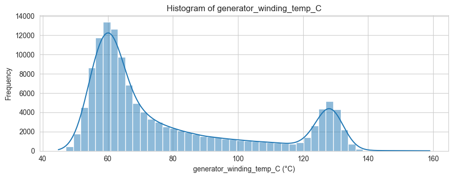

```
Count (non-null): 131760
Mean: 78.593, Median: 66.189, Std: 25.954
Q1: 59.489, Q3: 92.931, IQR: 33.442
Min: 44.771, Max: 158.996
```

```python
# Histogram and summary for `generator_winding_temp_C`
histogram(wind_df_preprocessed, 'generator_winding_temp_C', title='Histogram of generator_winding_temp_C', xlabel='generator_winding_temp_C (°C)')

# Print concise numerical summary
s = wind_df_preprocessed['generator_winding_temp_C'].dropna()
print(f"Count (non-null): {s.shape[0]}")
print(f"Mean: {s.mean():.3f}, Median: {s.median():.3f}, Std: {s.std():.3f}")
print(f"Q1: {s.quantile(0.25):.3f}, Q3: {s.quantile(0.75):.3f}, IQR: {s.quantile(0.75)-s.quantile(0.25):.3f}")
print(f"Min: {s.min()}, Max: {s.max()}")
```

**Observations**

- Central tendency: mean ≈ 78.59°C, median ≈ 66.19°C.
- Shape: strongly right-skewed (skewness ≈ 1.01) with a long upper tail.
- Interpretation:
  - Most generator winding temperatures sit in the ~55–70°C band (normal operation).
  - The long right tail and high max values (>140°C) indicate occasional extreme heating.

### `drivetrain_vibration_rms_mmps`

Generate a histogram of the `drivetrain_vibration_rms_mmps` feature. Observe where most vibration values are concentrated, assess the spread of the data, and identify any skewness or unusual values.

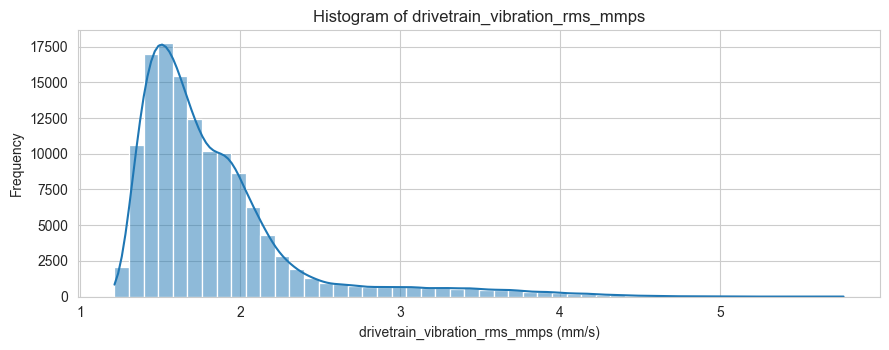

```
Count (non-null): 131760
Mean: 1.835, Median: 1.692, Std: 0.515
Q1: 1.506, Q3: 1.976, IQR: 0.470
Min: 1.216, Max: 5.77
```

```python
# Histogram and summary for `drivetrain_vibration_rms_mmps`
histogram(wind_df_preprocessed, 'drivetrain_vibration_rms_mmps', title='Histogram of drivetrain_vibration_rms_mmps', xlabel='drivetrain_vibration_rms_mmps (mm/s)')

# Print concise numerical summary
s = wind_df_preprocessed['drivetrain_vibration_rms_mmps'].dropna()
print(f"Count (non-null): {s.shape[0]}")
print(f"Mean: {s.mean():.3f}, Median: {s.median():.3f}, Std: {s.std():.3f}")
print(f"Q1: {s.quantile(0.25):.3f}, Q3: {s.quantile(0.75):.3f}, IQR: {s.quantile(0.75)-s.quantile(0.25):.3f}")
print(f"Min: {s.min()}, Max: {s.max()}")
```

**Observations**

- Shape: strongly right-skewed (skewness ≈ 2.28) with a long upper tail.
- Interpretation:
  - Typical drivetrain vibration values are clustered tightly most observations indicate normal vibration levels.
  - The heavy right tail contains rare higher-energy vibration events that may correlate with faults—worth correlating with failure labels.

### `tower_vibration_mmps`

Generate a histogram of the `tower_vibration_mmps` feature. Observe where most tower vibration values are concentrated, assess the spread of the data, and identify any skewness or unusual values.

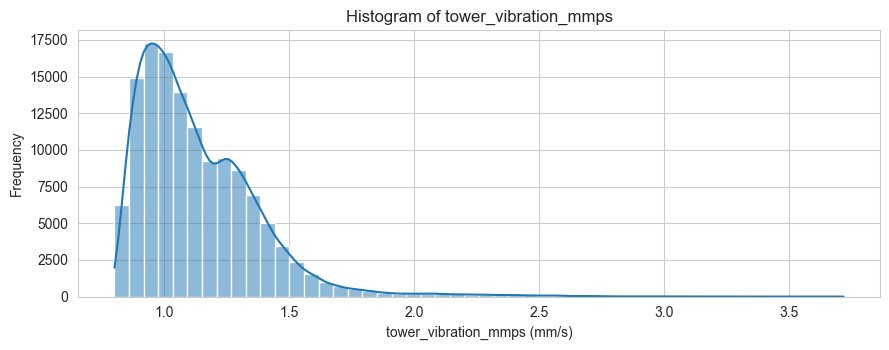

```
Count (non-null): 131760
Mean: 1.135, Median: 1.079, Std: 0.243
Q1: 0.957, Q3: 1.265, IQR: 0.308
Min: 0.801, Max: 3.717
```

```python
# Histogram and summary for `tower_vibration_mmps`
histogram(wind_df_preprocessed, 'tower_vibration_mmps', title='Histogram of tower_vibration_mmps', xlabel='tower_vibration_mmps (mm/s)')

# Print concise numerical summary
s = wind_df_preprocessed['tower_vibration_mmps'].dropna()
print(f"Count (non-null): {s.shape[0]}")
print(f"Mean: {s.mean():.3f}, Median: {s.median():.3f}, Std: {s.std():.3f}")
print(f"Q1: {s.quantile(0.25):.3f}, Q3: {s.quantile(0.75):.3f}, IQR: {s.quantile(0.75)-s.quantile(0.25):.3f}")
print(f"Min: {s.min()}, Max: {s.max()}")
```

**Observations**

- Shape: strongly right-skewed (skewness ≈ 1.82) with a long upper tail.

### `oil_particle_count`

Generate a histogram of the `oil_particle_count` feature. Observe where most oil particle count values are concentrated, assess the spread of the data, and identify any skewness or unusual values.

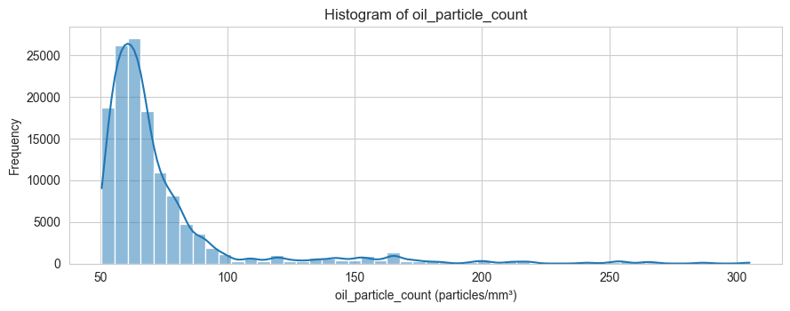

```
Count (non-null): 131760
Mean: 73.727, Median: 64.653, Std: 31.392
Q1: 58.554, Q3: 74.938, IQR: 16.384
Min: 50.565, Max: 305.105
```

```python
# Histogram and summary for `oil_particle_count`
histogram(wind_df_preprocessed, 'oil_particle_count', title='Histogram of oil_particle_count', xlabel='oil_particle_count (particles/mm³)')

# Print concise numerical summary
s = wind_df_preprocessed['oil_particle_count'].dropna()
print(f"Count (non-null): {s.shape[0]}")
print(f"Mean: {s.mean():.3f}, Median: {s.median():.3f}, Std: {s.std():.3f}")
print(f"Q1: {s.quantile(0.25):.3f}, Q3: {s.quantile(0.75):.3f}, IQR: {s.quantile(0.75)-s.quantile(0.25):.3f}")
print(f"Min: {s.min()}, Max: {s.max()}")
```

**Observations**

- Shape: strongly right-skewed (skewness ≈ 3.60) with a long upper tail; most values concentrated between ~50–100 (peak around ~60–75).
- Unusual values: sparse large values up to ~305 — treat as outliers or investigate measurement/maintenance events.

### `prior_fault_count`

Generate a histogram of the `prior_fault_count` feature. Observe where most prior fault count values are concentrated, assess the spread of the data, and identify any skewness or unusual values.

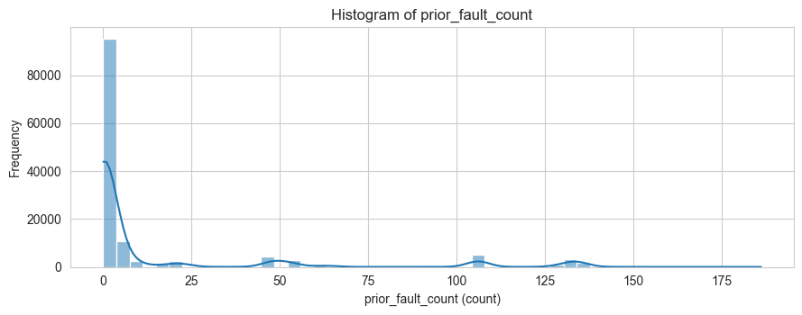

```
Count (non-null): 131760
Mean: 14.774, Median: 0.000, Std: 34.696
Q1: 0.000, Q3: 4.000, IQR: 4.000
Min: 0, Max: 186
```

```python
# Histogram and summary for `prior_fault_count`
histogram(wind_df_preprocessed, 'prior_fault_count', title='Histogram of prior_fault_count', xlabel='prior_fault_count (count)')

# Print concise numerical summary
s = wind_df_preprocessed['prior_fault_count'].dropna()
print(f"Count (non-null): {s.shape[0]}")
print(f"Mean: {s.mean():.3f}, Median: {s.median():.3f}, Std: {s.std():.3f}")
print(f"Q1: {s.quantile(0.25):.3f}, Q3: {s.quantile(0.75):.3f}, IQR: {s.quantile(0.75)-s.quantile(0.25):.3f}")
print(f"Min: {s.min()}, Max: {s.max()}")
```

**Observations**

- Shape: strongly right-skewed (skewness ≈ 2.52) with a heavy upper tail; the distribution is zero-inflated (many zeros).
- Unusual values: rare high counts up to 186 — investigate as outliers or aggregated event counts.

### `component_age_days`

Generate a histogram of the `component_age_days` feature. Observe where most component age values are concentrated, assess the spread of the data, and identify any skewness or unusual values.

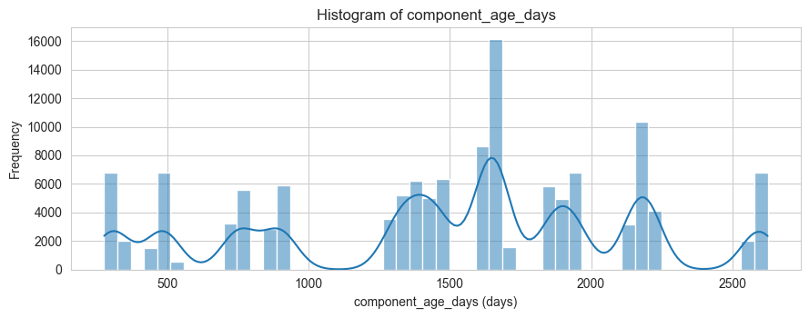

```
Count (non-null): 131760
Mean: 1487.999, Median: 1625.403, Std: 629.606
Q1: 912.710, Q3: 1921.924, IQR: 1009.213
Min: 276.015, Max: 2625.264
```

```python
# Histogram and summary for `component_age_days`
histogram(wind_df_preprocessed, 'component_age_days', title='Histogram of component_age_days', xlabel='component_age_days (days)')

# Print concise numerical summary
s = wind_df_preprocessed['component_age_days'].dropna()
print(f"Count (non-null): {s.shape[0]}")
print(f"Mean: {s.mean():.3f}, Median: {s.median():.3f}, Std: {s.std():.3f}")
print(f"Q1: {s.quantile(0.25):.3f}, Q3: {s.quantile(0.75):.3f}, IQR: {s.quantile(0.75)-s.quantile(0.25):.3f}")
print(f"Min: {s.min()}, Max: {s.max()}")
```

**Observations**

- Shape: slightly left-skewed (skewness ≈ -0.29); most values concentrated between ~900–2000 days, with fewer very young components (~276–900) and fewer very old (~2000–2600).
- Unusual values: no extreme outliers beyond expected operational age range, but check entries near min/max for data quality.

## Bivariate Analysis

### `turbine_id` vs `failure`

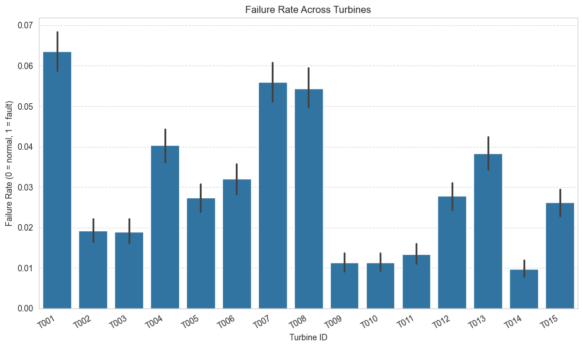

```python
barchart(data_df=wind_df_preprocessed, x_col='turbine_id', y_col='failure', title='Failure Rate Across Turbines', xlabel='Turbine ID', ylabel='Failure Rate (0 = normal, 1 = fault)')
```

### `wind_speed_mps` vs `power_output_kW`

Perform the following steps to analyze the relationship between wind speed and power output:

1. Group the `wind_speed_mps` values into intervals (bins).
2. Calculate the average `power_output_kW` for each wind speed interval.
3. Plot the average power output against the wind speed intervals.
4. Observe how power output changes as wind speed increases and identify any trends or patterns.

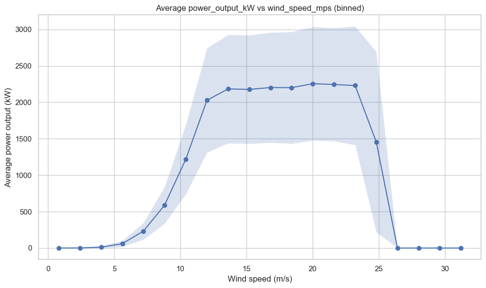

```python
bins = pd.cut(wind_df_preprocessed['wind_speed_mps'], bins=20)
agg = wind_df_preprocessed.groupby(bins)['power_output_kW'].agg(['mean','std','count']).reset_index()
agg['bin_center'] = agg['wind_speed_mps'].apply(lambda iv: iv.left + (iv.right-iv.left)/2)

plt.figure(figsize=(10,6))
plt.plot(agg['bin_center'], agg['mean'], marker='o')
plt.fill_between(agg['bin_center'], agg['mean']-agg['std'], agg['mean']+agg['std'], alpha=0.2)
plt.xlabel('Wind speed (m/s)')
plt.ylabel('Average power output (kW)')
plt.title('Average power_output_kW vs wind_speed_mps (binned)')
plt.grid(True)
plt.tight_layout()
plt.show()
```

**Observations**

- At very low wind speeds (below the turbine cut‑in) power is near zero.
- Power rises rapidly as wind speed increases (expected roughly as a power law), with mean power growing steeply through the mid-range.
- At higher wind speeds the mean power flattens into a plateau (the turbine’s rated power region).
- Variability (spread) of power increases with wind speed — larger std in mid/high bins.

### `rotor_speed_rpm` vs `generator_speed_rpm`

Generate a scatter plot using `rotor_speed_rpm` and `generator_speed_rpm`. Observe whether a relationship exists between the two variables, identify the overall trend, and look for any unusual observations or outliers.

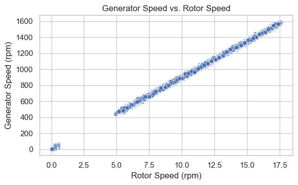

```python
scatterplot(data_df=wind_df_preprocessed, x_col='rotor_speed_rpm', y_col='generator_speed_rpm',
            title='Generator Speed vs. Rotor Speed',
            xlabel='Rotor Speed (rpm)',
            ylabel='Generator Speed (rpm)')
```

**Observations**

- Linear fit: generator_speed ≈ 89.9025 * rotor_speed + 1.238 (consistent gear ratio).
- Outliers: 414 points with residuals > 3σ — rare deviations possibly from sensor errors, transient states, or gearbox slip.

### `wind_speed_mps` vs `rotor_speed_rpm`

Generate a scatter plot using `wind_speed_mps` and `rotor_speed_rpm`. Observe how rotor speed changes with increasing wind speed, identify the overall relationship between the two variables, and look for any unusual observations or outliers.

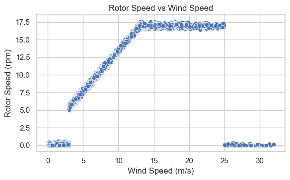

```python
scatterplot(data_df=wind_df_preprocessed, x_col='wind_speed_mps', y_col='rotor_speed_rpm',
            title='Rotor Speed vs Wind Speed',
            xlabel='Wind Speed (m/s)',
            ylabel='Rotor Speed (rpm)')
```

### `drivetrain_vibration_rms_mmps` vs `failure`

Generate a box plot of `drivetrain_vibration_rms_mmps` across the `failure` classes. Compare the distribution of vibration levels between normal and fault conditions, and identify any differences in central tendency, spread, and potential outliers.

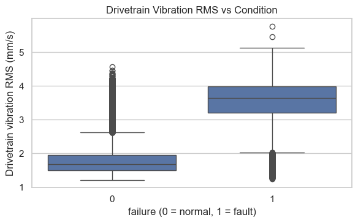

```python
boxplot(wind_df_preprocessed,
        x_col='failure',
        y_col='drivetrain_vibration_rms_mmps',
        title='Drivetrain Vibration RMS vs Condition',
        xlabel='failure (0 = normal, 1 = fault)',
        ylabel='Drivetrain vibration RMS (mm/s)')
```

**Observations**

- Central tendency: failure=1 has substantially higher median and mean vibration than failure=0.
- Spread: fault class shows larger spread (std ≈ 0.88 vs 0.41).
- Outliers: both classes have outliers above the upper whisker; more absolute outliers in the normal class due to its larger sample size, but fault class shows higher extreme values (up to ~5.77 mm/s).

### `oil_particle_count` vs `failure`

Generate a box plot of `oil_particle_count` across the `failure` classes. Compare the distribution of oil particle counts between normal and fault conditions, and identify any differences in central tendency, spread, and potential outliers.

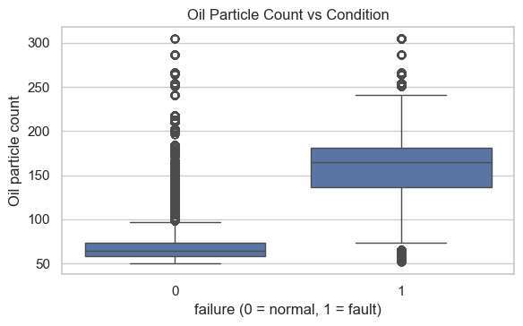

```python
boxplot(wind_df_preprocessed,
        x_col='failure',
        y_col='oil_particle_count',
        title='Oil Particle Count vs Condition',
        xlabel='failure (0 = normal, 1 = fault)',
        ylabel='Oil particle count')
```

**Observations**

- Central tendency: failure=1 shows substantially higher median and mean oil particle counts than failure=0.
- Outliers: more extreme counts in the fault class proportionally; some very high counts (up to ~305) likely indicate severe contamination or measurement aggregation.
- Interpretation: elevated oil particle counts are strongly associated with failures; consider using this feature directly or binned thresholds in models.

### `gearbox_bearing_temp_C` vs `failure`

Generate a box plot of `gearbox_bearing_temp_C` across the `failure` classes. Compare the distribution of gearbox bearing temperatures between normal and fault conditions, and identify any differences in central tendency, spread, and potential outliers.

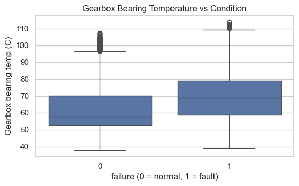

```python
boxplot(wind_df_preprocessed,
        x_col='failure',
        y_col='gearbox_bearing_temp_C',
        title='Gearbox Bearing Temperature vs Condition',
        xlabel='failure (0 = normal, 1 = fault)',
        ylabel='Gearbox bearing temp (C)')
```

**Observations**

- Central tendency: failure=1 shows higher mean and median gearbox bearing temperature than failure=0 (≈7–12°C higher).
- Spread: fault class has similar spread (std ≈ 14°C) but is shifted upward.
- Outliers: few outliers in both classes; the fault class has slightly higher maximums.
- Interpretation: elevated gearbox bearing temperature is associated with failures and could be a useful predictive signal.

### `power_output_kW` vs `failure`

Generate a box plot of `power_output_kW` across the `failure` classes. Compare the distribution of power output between normal and fault conditions, and identify any differences in central tendency, spread, and potential outliers.

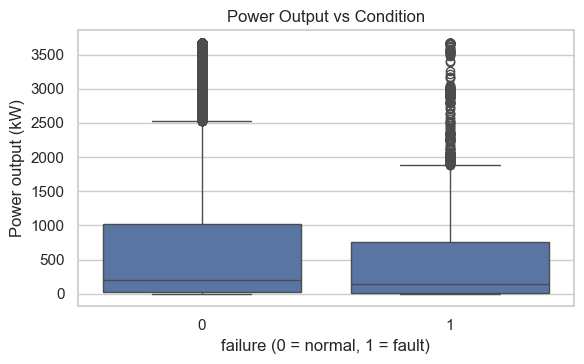

```python
boxplot(wind_df_preprocessed,
        x_col='failure',
        y_col='power_output_kW',
        title='Power Output vs Condition',
        xlabel='failure (0 = normal, 1 = fault)',
        ylabel='Power output (kW)')
```

**Observations**

- Central tendency: the fault class has lower median and mean power (median ~137 kW vs ~201 kW normal), suggesting failures more often occur at lower-than-typical power states.
- Spread: both classes show very large spread and heavy right tails (max up to 3672 kW). High variability likely from operating range (cut‑in to rated power) and occasional extreme values.
- Outliers: many high-power outliers in both classes; consider trimming or using log-scale when modeling.
- Interpretation: failures are not concentrated at high power — they appear more frequently at lower power outputs relative to normal operation; combine with other features (vibration, oil particle count, temps) for predictive power.

### `prior_fault_count` vs `failure`

Generate a box plot of `prior_fault_count` across the `failure` classes. Compare the distribution of prior fault counts between normal and fault conditions, and identify any differences in central tendency, spread, and potential outliers.

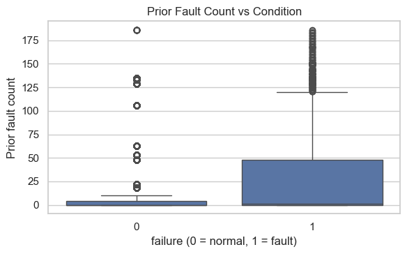

```python
boxplot(wind_df_preprocessed,
        x_col='failure',
        y_col='prior_fault_count',
        title='Prior Fault Count vs Condition',
        xlabel='failure (0 = normal, 1 = fault)',
        ylabel='Prior fault count')
```

**Observations**

- Central tendency: failure=1 shows higher mean and median prior fault counts than failure=0.
- Spread: fault class has much larger spread and higher upper quartile — many turbines with prior faults tend to have more prior events.
- Outliers: many high prior-fault counts, especially in the normal class numerically due to sample size; consider capping or log-transform for modeling.
- Interpretation: prior fault history is clearly informative — higher prior_fault_count correlates with current failure.

### `failure` vs `hour`

Perform the following steps to analyze how failure rates vary throughout the day:

1. Calculate the failure rate for each hour of the day.
2. Convert the failure rate into percentage values for easier interpretation.
3. Generate a bar chart to visualize the hourly failure rates.
4. Identify the hours with the highest and lowest failure rates, and observe any time-based patterns in failures.

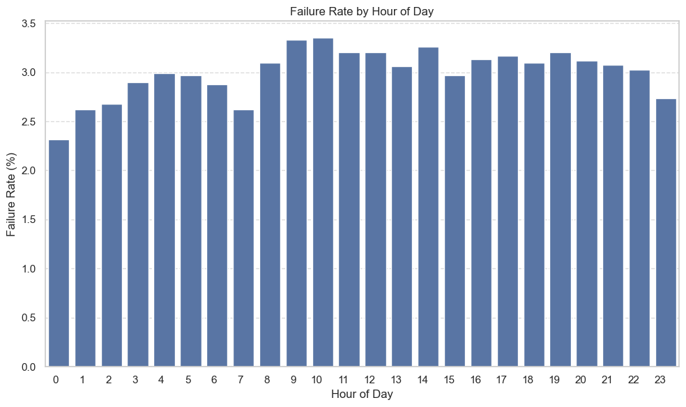

```python
# Calculate failure rate by hour
failure_rate_by_hour_df = wind_df_preprocessed.groupby('hour')['failure'].mean().reset_index()
failure_rate_by_hour_df['failure_rate_pct'] = failure_rate_by_hour_df['failure'] * 100

# Plot using the barchart utility function
barchart(data_df=failure_rate_by_hour_df, x_col='hour', y_col='failure_rate_pct',
         title='Failure Rate by Hour of Day',
         xlabel='Hour of Day', ylabel='Failure Rate (%)', rot_degrees=0)
```

**Observations**

- Peak failure window around 09:00–11:00 and 14:00–20:00 (hour 10 highest at ~3.35%).
- Lowest failure rate around midnight (hour 0 ~2.31%).
- Absolute differences are modest (~1 percentage point between lowest and highest), but consistent multi-hour peaks suggest diurnal patterns—investigate operational schedules or maintenance windows.

### `failure` vs `dayofweek`

Perform the following steps to analyze how failure rates vary across the days of the week:

1. Calculate the failure rate for each day of the week.
2. Convert the failure rate into percentage values for easier interpretation.
3. Arrange the days in chronological order from Monday to Sunday.
4. Generate a bar chart to visualize the failure rates across the week.
5. Identify the days with the highest and lowest failure rates, and observe any weekly patterns in failures.

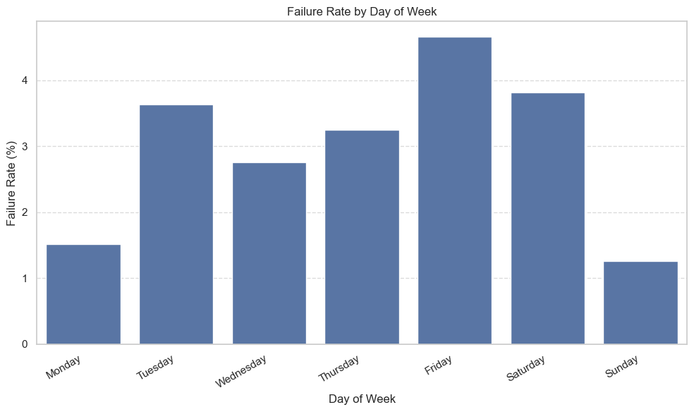

```python
df = wind_df_preprocessed.copy()

# preferred: build day names from a datetime column if available
datetime_cols = [c for c in df.columns if any(k in c.lower() for k in ('time','date','timestamp'))]
if datetime_cols:
    dt = pd.to_datetime(df[datetime_cols[0]], errors='coerce')
    if not dt.isna().all():
        df['day_name'] = dt.dt.day_name()
    else:
        df['day_name'] = np.nan
else:
    df['day_name'] = np.nan

# fallback: if numeric 0-6 day_of_week exists, map it
if 'day_of_week' in df.columns:
    if np.issubdtype(df['day_of_week'].dtype, np.integer) or np.issubdtype(df['day_of_week'].dtype, np.floating):
        day_name_map = {0: 'Monday',1:'Tuesday',2:'Wednesday',3:'Thursday',4:'Friday',5:'Saturday',6:'Sunday'}
        df.loc[df['day_name'].isna(), 'day_name'] = df['day_of_week'].map(day_name_map)
    else:
        # if it's already names/strings, normalize capitalization and use them
        df.loc[df['day_name'].isna(), 'day_name'] = df['day_of_week'].astype(str).str.strip().str.capitalize()

# final check: drop rows without a day name
df = df.dropna(subset=['day_name'])

# compute failure rate (%) and order days Mon->Sun
day_order = ['Monday','Tuesday','Wednesday','Thursday','Friday','Saturday','Sunday']
failure_rate_by_day_df = (df.groupby('day_name')['failure']
                           .mean()
                           .reindex(day_order)            # ensures chronological order, inserts NaN for missing days
                           .reset_index()
                           .rename(columns={'failure':'failure_rate'}) )
failure_rate_by_day_df['failure_rate_pct'] = failure_rate_by_day_df['failure_rate'] * 100
failure_rate_by_day_df = failure_rate_by_day_df.fillna(0)  # optional: set missing-day rates to 0

# plot using your existing barchart helper
barchart(data_df=failure_rate_by_day_df, x_col='day_name', y_col='failure_rate_pct',
         title='Failure Rate by Day of Week',
         xlabel='Day of Week', ylabel='Failure Rate (%)', rot_degrees=30)
```

## Multivariate Analysis

### Correlation Analysis

Create a list of all numerical features that will be used for correlation analysis. These features will be used to examine relationships between numerical variables and identify patterns that may be useful for further analysis and model building.

```python
numerical_cols = ['rated_power_kW', 'wind_speed_mps', 'wind_direction_deg', 'turbulence_intensity', 'air_density_kgm3',
                  'ambient_temp_C', 'humidity_pct', 'power_output_kW', 'rotor_speed_rpm', 'generator_speed_rpm', 'blade_pitch_angle_deg',
                  'yaw_misalignment_deg', 'gearbox_oil_temp_C', 'gearbox_bearing_temp_C', 'generator_bearing_temp_C', 'generator_winding_temp_C',
                  'main_bearing_temp_C', 'nacelle_temp_C', 'drivetrain_vibration_rms_mmps', 'tower_vibration_mmps', 'vib_fft_bearing_bpfo',
                  'vib_fft_bearing_bpfi', 'vib_fft_gearmesh', 'vib_fft_sideband', 'oil_particle_count', 'oil_pressure_bar', 'operating_hours_total',
                  'cumulative_energy_MWh', 'load_cycles', 'hours_since_last_maintenance', 'prior_fault_count', 'component_age_days']
```

Generate a correlation matrix for the numerical features. Examine the strength and direction of relationships between variables, identify highly correlated feature pairs, and look for potential multicollinearity that may affect model performance.

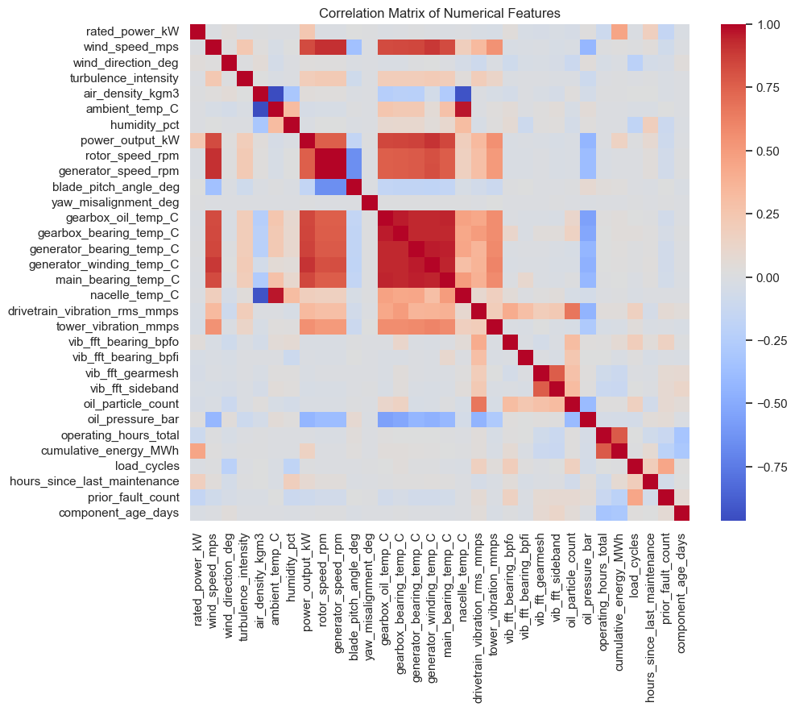

```python
plt.figure(figsize=(10, 8))
sns.heatmap(wind_df_preprocessed[numerical_cols].corr(), annot=False, cmap='coolwarm', fmt=".2f")
plt.title('Correlation Matrix of Numerical Features')
plt.show()
```

**Observations**

- Very strong linear pair: rotor_speed_rpm ↔ generator_speed_rpm: r ≈ 0.9998 — effectively redundant.
- Density vs temperature (expected negative): air_density_kgm3 strongly negative with ambient_temp_C and nacelle_temp_C (r ≈ -0.93 to -0.96).
- Moderately high correlations: power_output_kW ↔ generator_bearing_temp_C r ≈ 0.86 — useful but may contribute to multicollinearity when combined with other temps.
- Wind/power/speed relationships: wind_speed_mps correlates strongly with rotor_speed_rpm and generator_speed_rpm (r ≈ 0.91), and with generator temperatures; power_output_kW correlates with generator temps and wind speed (r up to ≈ 0.90).

# **Data Preprocessing**

## Splitting the data into train, validation, and test sets

This data is **panel time-series**: 15 turbines, each logged every 10 minutes over two months, and a single degradation episode spans many consecutive rows. A random split would scatter rows from the same episode across train and test, letting the model effectively see failures it is later scored on - inflating every metric.

```python
data = wind_df_preprocessed.sort_values(by=['timestamp','turbine_id'])
```

```python
n = len(data)
print(n)
```

```
131760
```

```python
# Uncomment the below train and validation indices to create a 70% train, 15% validation, and 15% test split.
i_train = int(n * 0.70)
i_val = int(n * 0.85)

# Uncomment the below train and validation indices to create a 90% train, 5% validation, and 5% test split.
# i_train = int(n * 0.90)
# i_val = int(n * 0.95)

# Uncomment the below train and validation indices to create a 80% train, 10% validation, and 10% test split.
# i_train = int(n * 0.80)
# i_val = int(n * 0.90)
```

```python
data_train = data.iloc[:i_train]

data_val = data.iloc[i_train:i_val]
data_test = data.iloc[i_val:]

X_train = data_train.drop(columns=['failure', 'timestamp', 'turbine_id'])
y_train = data_train['failure']

X_valid = data_val.drop(columns=['failure', 'timestamp', 'turbine_id'])
y_valid = data_val['failure']

X_test = data_test.drop(columns=['failure', 'timestamp', 'turbine_id'])
y_test = data_test['failure']
```

```python
print(f'Train split failure rate: {y_train.mean()*100:.2f}%')
print(f'Validation split failure rate: {y_valid.mean()*100:.2f}%')
print(f'Test split failure rate: {y_test.mean()*100:.2f}%')
```

```
Train split failure rate: 1.60%
Validation split failure rate: 5.26%
Test split failure rate: 7.29%
```

**Observations**

- The dataset contains 131,760 records and is sorted chronologically (then by turbine), which is appropriate for this panel time-series data and avoids leakage from randomly mixing related failure episodes.
- A 70% / 15% / 15% chronological split was used.
- Failure rates rise across time: 1.60% in training, 5.26% in validation, and 7.29% in test. This suggests failures become more common later in the observation period—possible evidence of degradation or temporal drift. It also confirms strong class imbalance.
- failure, timestamp, and turbine_id are excluded from the model-input feature sets. Removing the target is required, and removing identifiers/timestamps helps avoid direct leakage.

## Missing Value Treatment

### Display the percentage of missing values

Check the percentage of missing values in the training, validation, and test datasets. Identify the features with missing values before selecting an appropriate imputation strategy.

```python
print(((X_train.isnull().sum() / len(X_train) * 100).round(2)).loc[lambda x: x > 0])
print(((X_valid.isnull().sum() / len(X_valid) * 100).round(2)).loc[lambda x: x > 0])
print(((X_test.isnull().sum() / len(X_test) * 100).round(2)).loc[lambda x: x > 0])
```

```
gearbox_oil_temp_C          0.50
generator_bearing_temp_C    0.52
oil_pressure_bar            0.47
dtype: float64
gearbox_oil_temp_C          0.49
generator_bearing_temp_C    0.54
oil_pressure_bar            0.51
dtype: float64
gearbox_oil_temp_C          0.46
generator_bearing_temp_C    0.54
oil_pressure_bar            0.51
dtype: float64
```

### `gearbox_oil_temp_C`

Perform the following steps to handle missing values in the `gearbox_oil_temp_C` feature:

1. Choose an imputation strategy (`mean`, `median`, or `mode`) based on the distribution of the feature.
2. Calculate the selected statistic using only the training data.
3. Use the calculated value to fill the missing values in the training, validation, and test datasets.
4. Apply the same imputation value across all three datasets to ensure a consistent preprocessing strategy and prevent data leakage.

```python
# Choosing Median for the imputation strategy
oil_temp_train_stat = X_train['gearbox_oil_temp_C'].median()

#Fill missing values in the 'gearbox_oil_temp_C' column with the median value calculated from the training set.
X_train['gearbox_oil_temp_C'] = X_train['gearbox_oil_temp_C'].fillna(oil_temp_train_stat)
X_valid['gearbox_oil_temp_C'] = X_valid['gearbox_oil_temp_C'].fillna(oil_temp_train_stat)
X_test['gearbox_oil_temp_C']  = X_test['gearbox_oil_temp_C'].fillna(oil_temp_train_stat)

# Verify that no missing values remain.
print(f"Training median used: {oil_temp_train_stat:.2f}")
print("Missing values after imputation:")
print("Train:", X_train['gearbox_oil_temp_C'].isna().sum())
print("Validation:", X_valid['gearbox_oil_temp_C'].isna().sum())
print("Test:", X_test['gearbox_oil_temp_C'].isna().sum())
```

```
Training median used: 53.92
Missing values after imputation:
Train: 0
Validation: 0
Test: 0
```

### `generator_bearing_temp_C`

Perform the following steps to handle missing values in the `generator_bearing_temp_C` feature:

1. Choose an imputation strategy (`mean`, `median`, or `mode`) based on the distribution of the feature.
2. Calculate the selected statistic using only the training data.
3. Use the calculated value to fill the missing values in the training, validation, and test datasets.
4. Apply the same imputation value across all three datasets to ensure a consistent preprocessing strategy and prevent data leakage.

**NOTE**: Why Median - none of these distributions is symmetric. The two temperature variables are moderately right-skewed (skew ≈ 0.85), while oil pressure is strongly left-skewed (skew ≈ -1.77).

- Their means are therefore pulled toward the tails—for example, gearbox-oil temperature mean is 58.21°C versus median 54.31°C.
- The median is resistant to extreme operating/fault readings, so it is the safer and more representative fill value for these sensor variables.
- Mode is less suitable because these are continuous measurements, where an exact repeated value has limited meaning.

```python
# Choosing Median for the imputation strategy
bearing_temp_train_stat = X_train['generator_bearing_temp_C'].median()

# Fill missing values in the 'generator_bearing_temp_C' column with the median value calculated from the training set.
X_train['generator_bearing_temp_C'] = X_train['generator_bearing_temp_C'].fillna(bearing_temp_train_stat)
X_valid['generator_bearing_temp_C'] = X_valid['generator_bearing_temp_C'].fillna(bearing_temp_train_stat)
X_test['generator_bearing_temp_C']  = X_test['generator_bearing_temp_C'].fillna(bearing_temp_train_stat)

# Verify that no missing values remain.
print(f"Training median used: {bearing_temp_train_stat:.2f}")
print("Missing values after imputation:")
print("Train:", X_train['generator_bearing_temp_C'].isna().sum())
print("Validation:", X_valid['generator_bearing_temp_C'].isna().sum())
print("Test:", X_test['generator_bearing_temp_C'].isna().sum())
```

```
Training median used: 58.11
Missing values after imputation:
Train: 0
Validation: 0
Test: 0
```

### `oil_pressure_bar`

Perform the following steps to handle missing values in the `oil_pressure_bar` feature:

1. Choose an imputation strategy (`mean`, `median`, or `mode`) based on the distribution of the feature.
2. Calculate the selected statistic using only the training data.
3. Use the calculated value to fill the missing values in the training, validation, and test datasets.
4. Apply the same imputation value across all three datasets to ensure a consistent preprocessing strategy and prevent data leakage.

```python
# Choosing Median for the imputation strategy
oil_pressure_train_stat = X_train['oil_pressure_bar'].median()

# Fill missing values in the 'oil_pressure_bar' column with the median value calculated from the training set.
X_train['oil_pressure_bar'] = X_train['oil_pressure_bar'].fillna(oil_pressure_train_stat)
X_valid['oil_pressure_bar'] = X_valid['oil_pressure_bar'].fillna(oil_pressure_train_stat)
X_test['oil_pressure_bar'] = X_test['oil_pressure_bar'].fillna(oil_pressure_train_stat)

# Verify that no missing values remain.
print(f"Training median used: {oil_pressure_train_stat:.2f}")
print("Missing values after imputation:")
print("Train:", X_train['oil_pressure_bar'].isna().sum())
print("Validation:", X_valid['oil_pressure_bar'].isna().sum())
print("Test:", X_test['oil_pressure_bar'].isna().sum())
```

```
Training median used: 5.92
Missing values after imputation:
Train: 0
Validation: 0
Test: 0
```

# **Model Building**

**Note**: All five models provided in the subsequent subsections need to be built and evaluated.

## Model Evaluation Criterion

```python
# Uncomment one of the following evaluation metrics

# metric_of_choice = 'accuracy'
# metric_of_choice = 'precision'
# metric_of_choice = 'recall'
# metric_of_choice = 'f1'
```

## Utility Functions

Before moving ahead, we define a function to check the performance of the model using different metrics.

- We will be using metric functions defined in sklearn for accuracy, precision, recall, f1_score
- We will create a function which will print out all the above metrics in one go.

```python
def model_performance_classification(model, predictors, target):
    """
    Function to compute different metrics to check classification model performance

    model: classifier (sklearn or tensorflow)
    predictors: independent variables
    target: dependent variable
    """

    # 1. Get raw predictions
    pred_raw = model.predict(predictors)

    # 2. Check the shape or values to handle DL vs ML models safely
    # If the predictions are probabilities (floats between 0 and 1, not exactly 0 or 1)
    # We check if any value falls strictly between 0 and 1
    if np.issubdtype(pred_raw.dtype, np.floating) and not np.all(np.isin(pred_raw, [0.0, 1.0])):
        # FOR TENSORFLOW DL MODELS: threshold the probabilities at 0.5
        pred = (pred_raw > 0.5).astype(int)
    else:
        # FOR SKLEARN ML MODELS: use them directly
        pred = pred_raw

    # Flatten predictions to ensure they match target shape perfectly
    pred = np.array(pred).flatten()

    # 3. Compute metrics
    acc = accuracy_score(target, pred)
    recall = recall_score(target, pred)
    precision = precision_score(target, pred)
    f1 = f1_score(target, pred)

    # 4. Creating a dataframe of metrics
    data_perf = pd.DataFrame(
        {"Accuracy": acc, "Recall": recall, "Precision": precision, "F1": f1},
        index=[0],
    )

    return data_perf
```

```python
def plot_confusion_matrix(model, predictors, target):
    """
    To plot the confusion_matrix with percentages

    model: classifier
    predictors: independent variables
    target: dependent variable
    """
    # 1. Get raw predictions
    y_pred_raw = model.predict(predictors)

    # 2. Check if predictions are probabilities (typical for Keras/TF models or some ML models with predict_proba)
    # If y_pred_raw contains float values between 0 and 1, it's likely probabilities.
    if np.issubdtype(y_pred_raw.dtype, np.floating) and np.any((y_pred_raw > 0) & (y_pred_raw < 1)):
        # Binarize probabilities using a threshold (e.g., 0.5)
        y_pred = (y_pred_raw > 0.5).astype(int)
    else:
        # Use predictions directly (typical for scikit-learn classifiers that return binary labels)
        y_pred = y_pred_raw

    # Ensure y_pred is flattened to a 1D array, as confusion_matrix expects this format.
    y_pred = np.array(y_pred).flatten()

    cm = confusion_matrix(target, y_pred)
    labels = np.asarray(
        [
            ["{0:0.0f}".format(item) + "\n{0:.2%}".format(item / cm.flatten().sum())]
            for item in cm.flatten()
        ]
    ).reshape(2, 2)

    plt.figure(figsize=(6, 4))
    sns.heatmap(cm, annot=labels, fmt="")
    plt.ylabel("True label")
    plt.xlabel("Predicted label")
    plt.show() # Added plt.show() to explicitly display the plot
```

## Decision Tree Classifier

Perform the following steps to train and evaluate the Decision Tree model:

1. Create a Decision Tree classifier using `class_weight='balanced'` to assign higher importance to the minority class and reduce the impact of class imbalance.
2. Train the model using the training dataset.
3. Evaluate the model on the training dataset by generating a confusion matrix and computing the performance metrics.
4. Evaluate the model on the validation dataset by generating a confusion matrix and computing the performance metrics.
5. Compare the training and validation results to assess how well the model generalizes and identify any signs of overfitting or underfitting.

```
Training Confusion Matrix
```

```
Training Performance Metrics
```

|  | Accuracy | Recall | Precision | F1 |
| --- | --- | --- | --- | --- |
| 0 | 1.0 | 1.0 | 1.0 | 1.0 |

```
Validation Confusion Matrix
```

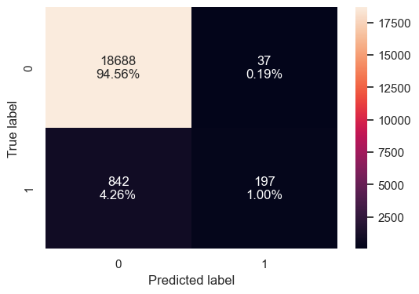

```
Validation Performance Metrics
```

|  | Accuracy | Recall | Precision | F1 |
| --- | --- | --- | --- | --- |
| 0 | 0.955525 | 0.189605 | 0.84188 | 0.309505 |

|  |  | Accuracy | Recall | Precision | F1 |
| --- | --- | --- | --- | --- | --- |
| Training | 0 | 1.000000 | 1.000000 | 1.00000 | 1.000000 |
| Validation | 0 | 0.955525 | 0.189605 | 0.84188 | 0.309505 |

```python
# Convert the categorical day-of-week feature into numeric dummy variables.
# Align validation columns with training columns.
X_train_tree = pd.get_dummies(X_train, columns=['day_of_week'], dtype=int)
X_valid_tree = pd.get_dummies(X_valid, columns=['day_of_week'], dtype=int)

X_valid_tree = X_valid_tree.reindex(columns=X_train_tree.columns, fill_value=0)

# Create and train a class-balanced Decision Tree model.
dt_model = DecisionTreeClassifier(
    class_weight='balanced',
    random_state=42
)

dt_model.fit(X_train_tree, y_train)

# Training-set evaluation
print("Training Confusion Matrix")
plot_confusion_matrix(dt_model, X_train_tree, y_train)

print("Training Performance Metrics")
dt_train_perf = model_performance_classification(dt_model, X_train_tree, y_train)
display(dt_train_perf)

# Validation-set evaluation
print("Validation Confusion Matrix")
plot_confusion_matrix(dt_model, X_valid_tree, y_valid)

print("Validation Performance Metrics")
dt_valid_perf = model_performance_classification(dt_model, X_valid_tree, y_valid)
display(dt_valid_perf)

# Compare model performance across the two splits
dt_comparison = pd.concat(
    [dt_train_perf, dt_valid_perf],
    keys=["Training", "Validation"]
)

display(dt_comparison)
```

[output not shown]

**Observations**

- The model achieves perfect performance on training data: accuracy, recall, precision, and F1-score are all 1.00. Its training confusion matrix has no errors.
- On validation data, performance drops substantially:
  - Accuracy: 95.55%
  - Recall: 18.96%
  - Precision: 84.19%
  - F1-score: 30.95%
- The model correctly identifies only 197 of 1,039 actual failures and misses 842 failures. This low recall is a major issue because the project aims to detect turbine failures.
- The high validation accuracy is misleading because normal cases dominate the data. A model can be accurate overall while still failing to detect most of the minority failure class.
- Precision is high, meaning that when the model predicts a failure, it is usually correct. However, it is too conservative in predicting failures.
- The large gap between perfect training performance and weak validation recall/F1 indicates strong overfitting. The unrestricted Decision Tree memorizes patterns in the training data but does not generalize well to unseen data.

## Random Forest Classifier

Perform the following steps to train and evaluate the Random Forest model:

1. Create a Random Forest classifier using `class_weight='balanced'` to assign higher importance to the minority class and reduce the impact of class imbalance.
2. Train the model using the training dataset.
3. Evaluate the model on the training dataset by generating a confusion matrix and computing the performance metrics.
4. Evaluate the model on the validation dataset by generating a confusion matrix and computing the performance metrics.
5. Compare the training and validation results to assess how well the model generalizes and identify any signs of overfitting or underfitting.

```
Training Confusion Matrix
```

```
Training Performance Metrics
```

|  | Accuracy | Recall | Precision | F1 |
| --- | --- | --- | --- | --- |
| 0 | 1.0 | 1.0 | 1.0 | 1.0 |

```
Validation Confusion Matrix
```

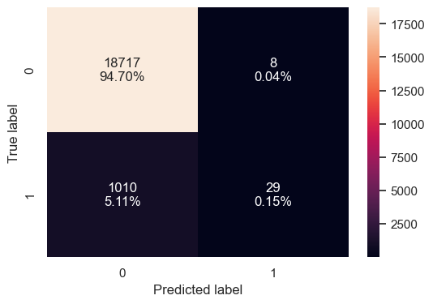

```
Validation Performance Metrics
```

|  | Accuracy | Recall | Precision | F1 |
| --- | --- | --- | --- | --- |
| 0 | 0.948492 | 0.027911 | 0.783784 | 0.053903 |

|  |  | Accuracy | Recall | Precision | F1 |
| --- | --- | --- | --- | --- | --- |
| Training | 0 | 1.000000 | 1.000000 | 1.000000 | 1.000000 |
| Validation | 0 | 0.948492 | 0.027911 | 0.783784 | 0.053903 |

```python
# Reuse the numeric, encoded feature sets created for the Decision Tree.
# If not already created, encode and align day_of_week first.
X_train_rf = pd.get_dummies(X_train, columns=['day_of_week'], dtype=int)
X_valid_rf = pd.get_dummies(X_valid, columns=['day_of_week'], dtype=int)

X_valid_rf = X_valid_rf.reindex(columns=X_train_rf.columns, fill_value=0)

# Create and train the class-balanced Random Forest model.
rf_model = RandomForestClassifier(
    n_estimators=100,
    class_weight='balanced',
    random_state=42,
    n_jobs=-1
)

rf_model.fit(X_train_rf, y_train)

# Training-set evaluation
print("Training Confusion Matrix")
plot_confusion_matrix(rf_model, X_train_rf, y_train)

print("Training Performance Metrics")
rf_train_perf = model_performance_classification(rf_model, X_train_rf, y_train)
display(rf_train_perf)

# Validation-set evaluation
print("Validation Confusion Matrix")
plot_confusion_matrix(rf_model, X_valid_rf, y_valid)

print("Validation Performance Metrics")
rf_valid_perf = model_performance_classification(rf_model, X_valid_rf, y_valid)
display(rf_valid_perf)

# Compare training and validation performance.
rf_comparison = pd.concat(
    [rf_train_perf, rf_valid_perf],
    keys=["Training", "Validation"]
)

display(rf_comparison)
```

[output not shown]

**Observations**

- Training performance is perfect: accuracy, recall, precision, and F1-score are all 1.00. The model makes no training errors.
- Validation performance is much weaker:
  - Accuracy: 94.85%
  - Recall: 2.79%
  - Precision: 78.38%
  - F1-score: 5.39%
- The model detects only 29 of 1,039 actual failures and misses 1,010 failures. This is extremely low recall and makes the model unsuitable for a failure-detection use case in its current form.
- Although precision is relatively high, the model predicts failure only 37 times, so it is highly conservative.
- Accuracy is again misleading because failures are rare; predicting normal for almost every case still produces high overall accuracy.
- The gap between perfect training performance and very poor validation recall/F1 indicates severe overfitting. Hyperparameter tuning—especially limiting max_depth, increasing min_samples_leaf, and adjusting class weighting or the decision threshold—will be necessary.

## Gradient Boosting Classifier

Perform the following steps to train and evaluate the Gradient Boosting model:

1. Create a Gradient Boosting classifier using the selected random state.
2. Train the model using the training dataset.
3. Evaluate the model on the training dataset by generating a confusion matrix and computing the performance metrics.
4. Evaluate the model on the validation dataset by generating a confusion matrix and computing the performance metrics.
5. Compare the training and validation results to assess how well the model generalizes and identify any signs of overfitting or underfitting.

```
Training Confusion Matrix
```

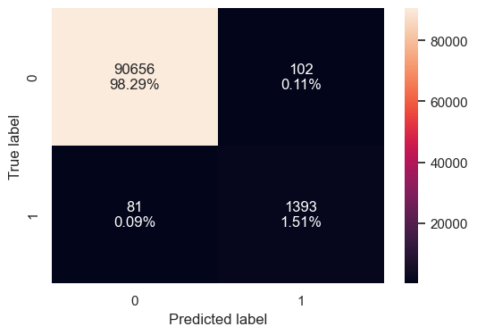

```
Training Performance Metrics
```

|  | Accuracy | Recall | Precision | F1 |
| --- | --- | --- | --- | --- |
| 0 | 0.998016 | 0.945047 | 0.931773 | 0.938363 |

```
Validation Confusion Matrix
```

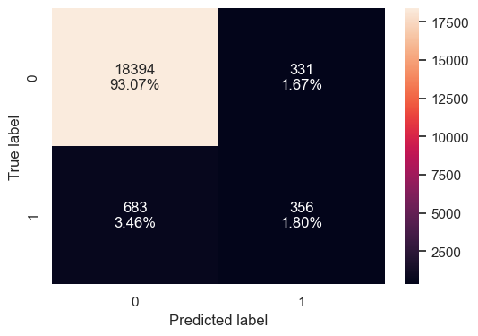

```
Validation Performance Metrics
```

|  | Accuracy | Recall | Precision | F1 |
| --- | --- | --- | --- | --- |
| 0 | 0.948695 | 0.342637 | 0.518195 | 0.412514 |

|  |  | Accuracy | Recall | Precision | F1 |
| --- | --- | --- | --- | --- | --- |
| Training | 0 | 0.998016 | 0.945047 | 0.931773 | 0.938363 |
| Validation | 0 | 0.948695 | 0.342637 | 0.518195 | 0.412514 |

```python
# Encode the categorical feature and align validation columns with training columns.
X_train_gb = pd.get_dummies(X_train, columns=['day_of_week'], dtype=int)
X_valid_gb = pd.get_dummies(X_valid, columns=['day_of_week'], dtype=int)

X_valid_gb = X_valid_gb.reindex(columns=X_train_gb.columns, fill_value=0)

# Create and train the Gradient Boosting model.
gb_model = GradientBoostingClassifier(
    random_state=42
)

gb_model.fit(X_train_gb, y_train)

# Training-set evaluation
print("Training Confusion Matrix")
plot_confusion_matrix(gb_model, X_train_gb, y_train)

print("Training Performance Metrics")
gb_train_perf = model_performance_classification(gb_model, X_train_gb, y_train)
display(gb_train_perf)

# Validation-set evaluation
print("Validation Confusion Matrix")
plot_confusion_matrix(gb_model, X_valid_gb, y_valid)

print("Validation Performance Metrics")
gb_valid_perf = model_performance_classification(gb_model, X_valid_gb, y_valid)
display(gb_valid_perf)

# Compare training and validation performance.
gb_comparison = pd.concat(
    [gb_train_perf, gb_valid_perf],
    keys=["Training", "Validation"]
)

display(gb_comparison)
```

**Observations**

- Training performance is very strong:
  - Accuracy: 99.80%
  - Recall: 94.50%
  - Precision: 93.18%
  - F1-score: 93.84%
- Validation performance decreases:
  - Accuracy: 94.87%
  - Recall: 34.26%
  - Precision: 51.82%
  - F1-score: 41.25%
- The model correctly detects 356 of 1,039 failures, which is substantially better than the Decision Tree (197) and Random Forest (29) baselines. However, it still misses 683 failures, so recall needs improvement for a turbine-failure detection use case.
- Unlike the previous models, Gradient Boosting shows less extreme overfitting: training performance is high, but validation F1-score remains meaningful rather than collapsing completely.
- There is still a clear training–validation gap—especially in recall (94.5% to 34.3%) and F1 (93.8% to 41.3%)—which indicates moderate overfitting.
- Validation accuracy is high but should not be the main selection metric because normal observations dominate the data. Validation recall and F1-score give a more realistic assessment.
- Further tuning and imbalance handling using training sample_weight would likely help increase failure recall.

## XGBoost

Perform the following steps to train and evaluate the XGBoost model:

1. Calculate the number of negative and positive samples in the training data.
2. Compute the `scale_pos_weight` value as the ratio of negative samples to positive samples to address class imbalance.
3. Create an XGBoost classifier using the calculated `scale_pos_weight` and the selected random state.
4. Train the model using the training dataset.
5. Evaluate the model on the training dataset by generating a confusion matrix and computing the performance metrics.
6. Evaluate the model on the validation dataset by generating a confusion matrix and computing the performance metrics.
7. Compare the training and validation results to assess how well the model generalizes and identify any signs of overfitting or underfitting.

```
Negative samples: 90758
Positive samples: 1474
scale_pos_weight: 61.57
Training Confusion Matrix
```

```
Training Performance Metrics
```

|  | Accuracy | Recall | Precision | F1 |
| --- | --- | --- | --- | --- |
| 0 | 1.0 | 1.0 | 1.0 | 1.0 |

```
Validation Confusion Matrix
```

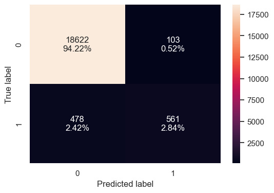

```
Validation Performance Metrics
```

|  | Accuracy | Recall | Precision | F1 |
| --- | --- | --- | --- | --- |
| 0 | 0.970603 | 0.539942 | 0.84488 | 0.658837 |

|  |  | Accuracy | Recall | Precision | F1 |
| --- | --- | --- | --- | --- | --- |
| Training | 0 | 1.000000 | 1.000000 | 1.00000 | 1.000000 |
| Validation | 0 | 0.970603 | 0.539942 | 0.84488 | 0.658837 |

```python
# Encode the categorical feature and align validation columns with training columns.
X_train_xgb = pd.get_dummies(X_train, columns=['day_of_week'], dtype=int)
X_valid_xgb = pd.get_dummies(X_valid, columns=['day_of_week'], dtype=int)

X_valid_xgb = X_valid_xgb.reindex(columns=X_train_xgb.columns, fill_value=0)

# Calculate class imbalance ratio using training labels only.
negative_samples = (y_train == 0).sum()
positive_samples = (y_train == 1).sum()

scale_pos_weight = negative_samples / positive_samples

print(f"Negative samples: {negative_samples}")
print(f"Positive samples: {positive_samples}")
print(f"scale_pos_weight: {scale_pos_weight:.2f}")

# Create and train the XGBoost model.
xgb_model = XGBClassifier(
    scale_pos_weight=scale_pos_weight,
    random_state=42,
    eval_metric="logloss"
)

xgb_model.fit(X_train_xgb, y_train)

# Training-set evaluation
print("Training Confusion Matrix")
plot_confusion_matrix(xgb_model, X_train_xgb, y_train)

print("Training Performance Metrics")
xgb_train_perf = model_performance_classification(xgb_model, X_train_xgb, y_train)
display(xgb_train_perf)

# Validation-set evaluation
print("Validation Confusion Matrix")
plot_confusion_matrix(xgb_model, X_valid_xgb, y_valid)

print("Validation Performance Metrics")
xgb_valid_perf = model_performance_classification(xgb_model, X_valid_xgb, y_valid)
display(xgb_valid_perf)

# Compare training and validation performance.
xgb_comparison = pd.concat(
    [xgb_train_perf, xgb_valid_perf],
    keys=["Training", "Validation"]
)

display(xgb_comparison)
```

[output not shown]

**Observations**

- The training data has 90,758 normal samples and 1,474 failure sample
- scale_pos_weight is 61.57, meaning a failure observation receives about 62 times the weighting of a normal observation during training.
- Training performance is perfect 100%.
- Validation performance is the strongest among the baseline models:
  - Accuracy: 97.06%
  - Recall: 53.99%
  - Precision: 84.49%
  - F1-score: 65.88%
- XGBoost identifies 561 of 1,039 actual failures and misses 478, making it much more effective at detecting failures than the earlier baseline Decision Tree, Random Forest, and Gradient Boosting models.
- Its high precision means most failure alerts are reliable: only 103 normal cases are incorrectly flagged.
- Despite excellent validation results, perfect training performance and lower validation recall/F1 indicate some overfitting. Still, the validation F1-score of 65.88% and recall of 53.99% show substantially better generalization than the other baseline models.
- XGBoost is the best baseline candidate so far, particularly because it balances strong failure detection with few false alarms.

## Neural Networks(ANN)

```python
tf.keras.backend.clear_session()
```

Perform the following steps to standardize the feature values:

1. Create a `StandardScaler` object to standardize the numerical features.
2. Fit the scaler using only the training dataset and transform the training features.
3. Use the same fitted scaler to transform the validation and test datasets.
4. Apply the same scaling parameters across all datasets to ensure a consistent preprocessing strategy and prevent data leakage.

```python
# Identify numerical columns from the training dataset.
numerical_features = X_train.select_dtypes(include=['int64', 'float64']).columns

# Create the scaler.
scaler = StandardScaler()

# Fit only on training data, then transform each split using the same fitted scaler.
X_train_scaled = X_train.copy()
X_valid_scaled = X_valid.copy()
X_test_scaled = X_test.copy()

X_train_scaled[numerical_features] = scaler.fit_transform(
    X_train[numerical_features]
)

X_valid_scaled[numerical_features] = scaler.transform(
    X_valid[numerical_features]
)

X_test_scaled[numerical_features] = scaler.transform(
    X_test[numerical_features]
)

# Optional verification: training numerical features should have mean ~0 and std ~1.
print("Training feature means after scaling:")
display(X_train_scaled[numerical_features].mean().round(2).head())

print("Training feature standard deviations after scaling:")
display(X_train_scaled[numerical_features].std().round(2).head())
```

```
Training feature means after scaling:
```

```
rated_power_kW         -0.0
wind_speed_mps          0.0
wind_direction_deg      0.0
turbulence_intensity    0.0
air_density_kgm3       -0.0
dtype: float64
```

```
Training feature standard deviations after scaling:
```

```
rated_power_kW          1.0
wind_speed_mps          1.0
wind_direction_deg      1.0
turbulence_intensity    1.0
air_density_kgm3        1.0
dtype: float64
```

Perform the following steps to build the neural network architecture:

1. Choose the number of neurons for the first hidden layer between **8 and 128**.
   - Fewer neurons (**8–32**) create a simpler model that trains faster and is less likely to overfit.
   - More neurons (**64–128**) enable the model to learn more complex patterns but increase training time and the risk of overfitting.
2. Choose an activation function for the first hidden layer (for example, `relu`, `tanh`, or `sigmoid`) based on the learning behavior you want.
3. Create the output layer with a single neuron and a `sigmoid` activation function to predict the probability of the positive class.

```python
# Neural networks require fully numeric inputs.
# Encode the categorical feature and align all feature columns.
X_train_nn = pd.get_dummies(X_train_scaled, columns=['day_of_week'], dtype=int)
X_valid_nn = pd.get_dummies(X_valid_scaled, columns=['day_of_week'], dtype=int)
X_test_nn = pd.get_dummies(X_test_scaled, columns=['day_of_week'], dtype=int)

X_valid_nn = X_valid_nn.reindex(columns=X_train_nn.columns, fill_value=0)
X_test_nn = X_test_nn.reindex(columns=X_train_nn.columns, fill_value=0)

# Build the neural network architecture.
ann_model = Sequential([
    tf.keras.Input(shape=(X_train_nn.shape[1],)),
    Dense(64, activation='relu'),     # First hidden layer
    Dense(1, activation='sigmoid')    # Output: predicted failure probability
])
```

Display the neural network architecture. Review the number of layers, the output shape of each layer, and the total number of trainable parameters before training the model.

```python
ann_model.summary()
```

```
Model: "sequential_1"
```

```
┏━━━━━━━━━━━━━━━━━━━━━━━━━━━━━━━━━┳━━━━━━━━━━━━━━━━━━━━━━━━┳━━━━━━━━━━━━━━━┓
┃ Layer (type)                    ┃ Output Shape           ┃       Param # ┃
┡━━━━━━━━━━━━━━━━━━━━━━━━━━━━━━━━━╇━━━━━━━━━━━━━━━━━━━━━━━━╇━━━━━━━━━━━━━━━┩
│ dense_2 (Dense)                 │ (None, 64)             │         2,624 │
├─────────────────────────────────┼────────────────────────┼───────────────┤
│ dense_3 (Dense)                 │ (None, 1)              │            65 │
└─────────────────────────────────┴────────────────────────┴───────────────┘
```

```
 Total params: 2,689 (10.50 KB)
```

```
 Trainable params: 2,689 (10.50 KB)
```

```
 Non-trainable params: 0 (0.00 B)
```

Perform the following steps to configure the neural network for training:

1. Choose an optimizer (`sgd` or `adam`) based on the desired training behavior.
   - `sgd` updates the model using simple gradient descent and may require more epochs to converge.
   - `adam` automatically adapts the learning rate, often converges faster, and is a common default choice.
2. Use `binary_crossentropy` as the loss function since this is a binary classification problem.
3. Configure the model to track **Recall**, **Precision**, and **Binary Accuracy** during training to evaluate its classification performance.

```python
ann_model.compile(
    optimizer='adam',
    loss='binary_crossentropy',
    metrics=[
        tf.keras.metrics.Recall(name='recall'),
        tf.keras.metrics.Precision(name='precision'),
        tf.keras.metrics.BinaryAccuracy(name='binary_accuracy')
    ]
)
```

Perform the following steps to configure the training process:

1. Choose the number of training epochs between **10 and 100** based on the desired training duration and model performance.
2. Select a batch size between **16 and 128** based on the available computational resources and training behavior.
3. Use the selected values to control how long the model trains and how many samples are processed in each weight update.

```python
epochs = 30
batch_size = 64
```

```python
weights = compute_class_weight('balanced', classes=np.unique(y_train), y=y_train)
class_weight_dict = {i: weights[i] for i in range(len(weights))}
```

```python
start = time.time()
history = ann_model.fit(
    X_train_nn,
    y_train,
    validation_data=(X_valid_nn,y_valid),
    class_weight=class_weight_dict,
    batch_size=batch_size,
    epochs=epochs)
end = time.time()
```

```
1442/1442 ━━━━━━━━━━━━━━━━━━━━ 1s 509us/step - binary_accuracy: 0.9957 - loss: 0.0122 - precision: 0.7883 - recall: 0.9980 - val_binary_accuracy: 0.9626 - val_loss: 1.0928 - val_precision: 0.7125 - val_recall: 0.4841
1442/1442 ━━━━━━━━━━━━━━━━━━━━ 1s 369us/step - binary_accuracy: 0.9956 - loss: 0.0113 - precision: 0.7866 - recall: 0.9980 - val_binary_accuracy: 0.9613 - val_loss: 1.0643 - val_precision: 0.7188 - val_recall: 0.4331
1442/1442 ━━━━━━━━━━━━━━━━━━━━ 1s 368us/step - binary_accuracy: 0.9958 - loss: 0.0106 - precision: 0.7928 - recall: 0.9993 - val_binary_accuracy: 0.9630 - val_loss: 1.0783 - val_precision: 0.6833 - val_recall: 0.5525
1442/1442 ━━━━━━━━━━━━━━━━━━━━ 1s 370us/step - binary_accuracy: 0.9956 - loss: 0.0115 - precision: 0.7828 - recall: 1.0000 - val_binary_accuracy: 0.9632 - val_loss: 1.0205 - val_precision: 0.7016 - val_recall: 0.5226
1442/1442 ━━━━━━━━━━━━━━━━━━━━ 1s 401us/step - binary_accuracy: 0.9956 - loss: 0.0111 - precision: 0.7832 - recall: 1.0000 - val_binary_accuracy: 0.9638 - val_loss: 1.0379 - val_precision: 0.7031 - val_recall: 0.5380
1442/1442 ━━━━━━━━━━━━━━━━━━━━ 1s 431us/step - binary_accuracy: 0.9957 - loss: 0.0117 - precision: 0.7872 - recall: 0.9986 - val_binary_accuracy: 0.9631 - val_loss: 1.0612 - val_precision: 0.6816 - val_recall: 0.5582
1442/1442 ━━━━━━━━━━━━━━━━━━━━ 1s 368us/step - binary_accuracy: 0.9957 - loss: 0.0107 - precision: 0.7902 - recall: 0.9993 - val_binary_accuracy: 0.9619 - val_loss: 1.0622 - val_precision: 0.6848 - val_recall: 0.5101
1442/1442 ━━━━━━━━━━━━━━━━━━━━ 1s 398us/step - binary_accuracy: 0.9958 - loss: 0.0103 - precision: 0.7929 - recall: 1.0000 - val_binary_accuracy: 0.9638 - val_loss: 1.0807 - val_precision: 0.6995 - val_recall: 0.5467
1442/1442 ━━━━━━━━━━━━━━━━━━━━ 1s 372us/step - binary_accuracy: 0.9959 - loss: 0.0102 - precision: 0.7968 - recall: 1.0000 - val_binary_accuracy: 0.9636 - val_loss: 1.0344 - val_precision: 0.7067 - val_recall: 0.5265
1442/1442 ━━━━━━━━━━━━━━━━━━━━ 1s 372us/step - binary_accuracy: 0.9954 - loss: 0.0125 - precision: 0.7776 - recall: 0.9986 - val_binary_accuracy: 0.9665 - val_loss: 1.1227 - val_precision: 0.7464 - val_recall: 0.5496
1442/1442 ━━━━━━━━━━━━━━━━━━━━ 1s 372us/step - binary_accuracy: 0.9960 - loss: 0.0098 - precision: 0.7989 - recall: 1.0000 - val_binary_accuracy: 0.9645 - val_loss: 1.0735 - val_precision: 0.7354 - val_recall: 0.5082
1442/1442 ━━━━━━━━━━━━━━━━━━━━ 1s 372us/step - binary_accuracy: 0.9959 - loss: 0.0105 - precision: 0.7959 - recall: 1.0000 - val_binary_accuracy: 0.9611 - val_loss: 1.0208 - val_precision: 0.7134 - val_recall: 0.4360
1442/1442 ━━━━━━━━━━━━━━━━━━━━ 1s 397us/step - binary_accuracy: 0.9956 - loss: 0.0115 - precision: 0.7846 - recall: 0.9986 - val_binary_accuracy: 0.9628 - val_loss: 0.9917 - val_precision: 0.7073 - val_recall: 0.4976
1442/1442 ━━━━━━━━━━━━━━━━━━━━ 1s 374us/step - binary_accuracy: 0.9959 - loss: 0.0105 - precision: 0.7968 - recall: 1.0000 - val_binary_accuracy: 0.9631 - val_loss: 1.0347 - val_precision: 0.7013 - val_recall: 0.5197
1442/1442 ━━━━━━━━━━━━━━━━━━━━ 1s 373us/step - binary_accuracy: 0.9960 - loss: 0.0099 - precision: 0.8007 - recall: 1.0000 - val_binary_accuracy: 0.9634 - val_loss: 1.0517 - val_precision: 0.7112 - val_recall: 0.5120
1442/1442 ━━━━━━━━━━━━━━━━━━━━ 1s 377us/step - binary_accuracy: 0.9959 - loss: 0.0104 - precision: 0.7958 - recall: 0.9993 - val_binary_accuracy: 0.9623 - val_loss: 1.0128 - val_precision: 0.6920 - val_recall: 0.5082
1442/1442 ━━━━━━━━━━━━━━━━━━━━ 1s 379us/step - binary_accuracy: 0.9961 - loss: 0.0097 - precision: 0.8050 - recall: 1.0000 - val_binary_accuracy: 0.9625 - val_loss: 1.1139 - val_precision: 0.7285 - val_recall: 0.4572
1442/1442 ━━━━━━━━━━━━━━━━━━━━ 1s 374us/step - binary_accuracy: 0.9961 - loss: 0.0103 - precision: 0.8046 - recall: 1.0000 - val_binary_accuracy: 0.9636 - val_loss: 1.0320 - val_precision: 0.7206 - val_recall: 0.5014
1442/1442 ━━━━━━━━━━━━━━━━━━━━ 1s 373us/step - binary_accuracy: 0.9961 - loss: 0.0100 - precision: 0.8020 - recall: 1.0000 - val_binary_accuracy: 0.9630 - val_loss: 1.0616 - val_precision: 0.7110 - val_recall: 0.4995
1442/1442 ━━━━━━━━━━━━━━━━━━━━ 1s 373us/step - binary_accuracy: 0.9958 - loss: 0.0114 - precision: 0.7919 - recall: 0.9993 - val_binary_accuracy: 0.9620 - val_loss: 1.1055 - val_precision: 0.6604 - val_recall: 0.5707
```

[output cut: 10 more lines]

```python
print("Time taken in seconds ",end-start)
```

```
Time taken in seconds  17.494297981262207
```

Perform the following steps to evaluate the neural network model:

1. Evaluate the model on the training dataset by generating a confusion matrix and computing the performance metrics.
2. Evaluate the model on the validation dataset by generating a confusion matrix and computing the performance metrics.
3. Compare the training and validation results to assess how well the model generalizes and identify any signs of overfitting or underfitting.

```
Training Confusion Matrix
2883/2883 ━━━━━━━━━━━━━━━━━━━━ 0s 165us/step
```

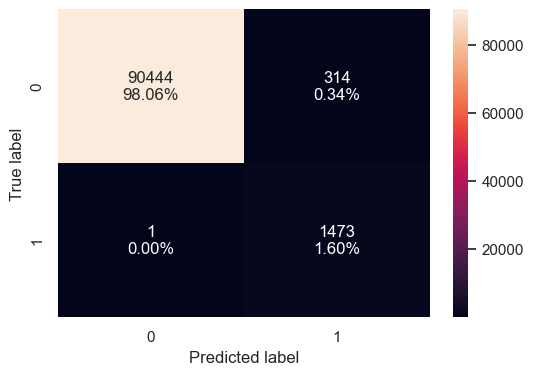

```
Training Performance Metrics
2883/2883 ━━━━━━━━━━━━━━━━━━━━ 0s 163us/step
```

|  | Accuracy | Recall | Precision | F1 |
| --- | --- | --- | --- | --- |
| 0 | 0.996585 | 0.999322 | 0.824287 | 0.903404 |

```
Validation Confusion Matrix
618/618 ━━━━━━━━━━━━━━━━━━━━ 0s 173us/step
```

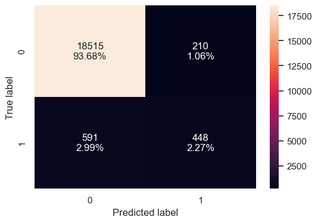

```
Validation Performance Metrics
618/618 ━━━━━━━━━━━━━━━━━━━━ 0s 234us/step
```

|  | Accuracy | Recall | Precision | F1 |
| --- | --- | --- | --- | --- |
| 0 | 0.959472 | 0.431184 | 0.680851 | 0.527991 |

|  |  | Accuracy | Recall | Precision | F1 |
| --- | --- | --- | --- | --- | --- |
| Training | 0 | 0.996585 | 0.999322 | 0.824287 | 0.903404 |
| Validation | 0 | 0.959472 | 0.431184 | 0.680851 | 0.527991 |

```python
# Training-set evaluation
print("Training Confusion Matrix")
plot_confusion_matrix(ann_model, X_train_nn, y_train)

print("Training Performance Metrics")
ann_train_perf = model_performance_classification(
    ann_model, X_train_nn, y_train
)
display(ann_train_perf)

# Validation-set evaluation
print("Validation Confusion Matrix")
plot_confusion_matrix(ann_model, X_valid_nn, y_valid)

print("Validation Performance Metrics")
ann_valid_perf = model_performance_classification(
    ann_model, X_valid_nn, y_valid
)
display(ann_valid_perf)

# Compare training and validation performance.
ann_comparison = pd.concat(
    [ann_train_perf, ann_valid_perf],
    keys=["Training", "Validation"]
)

display(ann_comparison)
```

**Observations**

- The ANN detects 448 of 1,039 failures and misses 591. Its recall is better than Gradient Boosting, but below XGBoost.
- The model produces 210 false alarms, so precision is moderate rather than exceptionally high.
- The sizeable drop from training F1 (90.34%) to validation F1 (52.79%) indicates overfitting, although the model still generalizes better than the Decision Tree and Random Forest baselines.
- Accuracy should not be used as the main metric because normal observations dominate. Validation recall and F1-score are more meaningful for failure detection.

## **Baseline Model Performance Comparison**

### Training performance comparison

Perform the following steps to compare the training performance of all baseline models:

1. Combine the training performance metrics of all baseline models into a single comparison table.
2. Display the consolidated table to compare the performance of each model across the selected evaluation metrics.
3. Use the comparison to identify the best-performing models for hyperparameter tuning.

```python
# Combine training metrics from all baseline models.
training_performance_comparison = pd.concat(
    [
        dt_train_perf.assign(Model="Decision Tree"),
        rf_train_perf.assign(Model="Random Forest"),
        gb_train_perf.assign(Model="Gradient Boosting"),
        xgb_train_perf.assign(Model="XGBoost"),
        ann_train_perf.assign(Model="ANN")
    ],
    ignore_index=True
)

# Place model name as the first column and display results.
training_performance_comparison = training_performance_comparison[
    ["Model", "Accuracy", "Recall", "Precision", "F1"]
]

display(training_performance_comparison.sort_values(
    by="F1",
    ascending=False
).reset_index(drop=True))
```

|  | Model | Accuracy | Recall | Precision | F1 |
| --- | --- | --- | --- | --- | --- |
| 0 | Decision Tree | 1.000000 | 1.000000 | 1.000000 | 1.000000 |
| 1 | Random Forest | 1.000000 | 1.000000 | 1.000000 | 1.000000 |
| 2 | XGBoost | 1.000000 | 1.000000 | 1.000000 | 1.000000 |
| 3 | Gradient Boosting | 0.998016 | 0.945047 | 0.931773 | 0.938363 |
| 4 | ANN | 0.996585 | 0.999322 | 0.824287 | 0.903404 |

### Validation performance comparison

Perform the following steps to compare the validation performance of all baseline models:

1. Combine the validation performance metrics of all baseline models into a single comparison table.
2. Display the consolidated table to compare the performance of each model across the selected evaluation metrics.
3. Use the comparison to identify the best-performing models for hyperparameter tuning based on their validation performance.

```python
# Combine validation metrics from all baseline models.
validation_performance_comparison = pd.concat(
    [
        dt_valid_perf.assign(Model="Decision Tree"),
        rf_valid_perf.assign(Model="Random Forest"),
        gb_valid_perf.assign(Model="Gradient Boosting"),
        xgb_valid_perf.assign(Model="XGBoost"),
        ann_valid_perf.assign(Model="ANN")
    ],
    ignore_index=True
)

# Place model name first and rank models by validation F1-score.
validation_performance_comparison = validation_performance_comparison[
    ["Model", "Accuracy", "Recall", "Precision", "F1"]
]

display(
    validation_performance_comparison
    .sort_values(by="F1", ascending=False)
    .reset_index(drop=True)
)
```

|  | Model | Accuracy | Recall | Precision | F1 |
| --- | --- | --- | --- | --- | --- |
| 0 | XGBoost | 0.970603 | 0.539942 | 0.844880 | 0.658837 |
| 1 | ANN | 0.959472 | 0.431184 | 0.680851 | 0.527991 |
| 2 | Gradient Boosting | 0.948695 | 0.342637 | 0.518195 | 0.412514 |
| 3 | Decision Tree | 0.955525 | 0.189605 | 0.841880 | 0.309505 |
| 4 | Random Forest | 0.948492 | 0.027911 | 0.783784 | 0.053903 |

**Observations**

- XGBoost is the strongest baseline model. It has the best validation F1-score, recall, precision, and accuracy. It detects the highest proportion of failures while keeping false alerts low.
- ANN is the second-best candidate. Its recall and F1-score are better than Gradient Boosting, but it raises more false alarms than XGBoost.
- Gradient Boosting offers moderate validation performance but misses about two-thirds of failures, so it is a lower-priority tuning candidate.
- Decision Tree and Random Forest should not be prioritized because their validation recall is very low—particularly Random Forest, which detects only about 3% of failures.
- Perfect or near-perfect training results for Decision Tree, Random Forest, and XGBoost indicate overfitting risk. Validation F1 and recall are therefore more useful than training metrics or accuracy for selecting models.

# **Hyperparameter Tuning**

**Note:** Choose at least two best-performing baseline models across the train and validation sets to proceed with tuning.

## XGBoost

Perform the following steps to define the hyperparameter search space for the XGBoost model:

1. Choose values for **`n_estimators`**, which controls the number of trees in the model. More trees can improve learning but increase training time.
2. Choose values for **`learning_rate`**, which controls how quickly the model learns. Smaller values require more trees, while larger values learn faster but may overshoot.
3. Choose values for **`max_depth`**, which controls the maximum depth of each tree. Deeper trees capture more complex patterns but are more likely to overfit.
4. Choose values for **`min_child_weight`**, which controls the minimum weight required to create a new split. Larger values produce more conservative trees.
5. Choose values for **`gamma`**, which specifies the minimum loss reduction required before making a split. Larger values reduce unnecessary splits.
6. Choose values for **`subsample`**, which determines the fraction of training samples used to build each tree. Lower values improve generalization, while higher values use more data.
7. Choose values for **`colsample_bytree`**, which specifies the fraction of features used to build each tree. Lower values increase diversity among trees.
8. Choose values for **`reg_alpha`** and **`reg_lambda`**, which apply L1 and L2 regularization to reduce overfitting.
9. Use the selected values to create the parameter grid for hyperparameter tuning and identify the best-performing model configuration.

```python
# Define the XGBoost hyperparameter search space.
xgb_param_grid = {
    "n_estimators": [100, 200, 300, 500],
    "learning_rate": [0.01, 0.03, 0.05, 0.1],
    "max_depth": [3, 4, 5, 6],
    "min_child_weight": [1, 3, 5, 7],
    "gamma": [0, 0.1, 0.3, 0.5],
    "subsample": [0.7, 0.8, 0.9, 1.0],
    "colsample_bytree": [0.7, 0.8, 0.9, 1.0],
    "reg_alpha": [0, 0.01, 0.1, 0.5],
    "reg_lambda": [0.5, 1, 2, 5]
}
```

Perform the following steps to tune the XGBoost model using randomized search:

1. Perform randomized search with **5-fold cross-validation** using the selected evaluation metric.
2. Train the model on each sampled hyperparameter combination and evaluate its cross-validation performance.
3. Display the best hyperparameter combination and its corresponding cross-validation score.

```python
# Base estimator retains imbalance weighting derived from y_train only.
xgb_tuning_model = XGBClassifier(
    scale_pos_weight=scale_pos_weight,
    random_state=42,
    eval_metric="logloss",
    n_jobs=1
)

# Random search efficiently evaluates a subset of possible configurations.
xgb_random_search = RandomizedSearchCV(
    estimator=xgb_tuning_model,
    param_distributions=xgb_param_grid,
    n_iter=30,
    scoring="f1",
    cv=5,
    n_jobs=-1,
    verbose=1,
    random_state=42
)

# Fit only on training data.
xgb_random_search.fit(X_train_xgb, y_train)

# Best tuned XGBoost model and configuration.
best_xgb_model = xgb_random_search.best_estimator_

print("Best XGBoost parameters:")
print(xgb_random_search.best_params_)

print(f"\nBest cross-validation F1-score: {xgb_random_search.best_score_:.4f}")
```

```
Fitting 5 folds for each of 30 candidates, totalling 150 fits
Best XGBoost parameters:
{'subsample': 0.8, 'reg_lambda': 1, 'reg_alpha': 0.01, 'n_estimators': 300, 'min_child_weight': 5, 'max_depth': 4, 'learning_rate': 0.01, 'gamma': 0, 'colsample_bytree': 0.8}

Best cross-validation F1-score: 0.4571
```

1. Retrieve the best-performing XGBoost model identified during the randomized search.
2. Retrain the selected model using the complete training dataset.
3. Use the retrained model for subsequent evaluation on the training, validation, and test datasets.

```python
# Retrieve the best XGBoost configuration found by randomized search.
best_xgb_model = xgb_random_search.best_estimator_

# Retrain the selected model on the complete training dataset.
best_xgb_model.fit(X_train_xgb, y_train)

# The retrained model is now ready for evaluation.
# Use:
# - X_train_xgb, y_train for training evaluation
# - X_valid_xgb, y_valid for validation evaluation
# - X_test_xgb, y_test for final test evaluation
```

```
XGBClassifier(base_score=None, booster=None, callbacks=None,
              colsample_bylevel=None, colsample_bynode=None,
              colsample_bytree=0.8, device=None, early_stopping_rounds=None,
              enable_categorical=False, eval_metric='logloss',
              feature_types=None, feature_weights=None, gamma=0,
              grow_policy=None, importance_type=None,
              interaction_constraints=None, learning_rate=0.01, max_bin=None,
              max_cat_threshold=None, max_cat_to_onehot=None,
              max_delta_step=None, max_depth=4, max_leaves=None,
              min_child_weight=5, missing=nan, monotone_constraints=None,
              multi_strategy=None, n_estimators=300, n_jobs=1,
              num_parallel_tree=None, ...)
```

```python
# Training performance of the tuned XGBoost model
print("Tuned XGBoost - Training Performance")
best_xgb_train_perf = model_performance_classification(
    best_xgb_model,
    X_train_xgb,
    y_train
)
display(best_xgb_train_perf)

# Validation performance of the tuned XGBoost model
print("Tuned XGBoost - Validation Performance")
best_xgb_valid_perf = model_performance_classification(
    best_xgb_model,
    X_valid_xgb,
    y_valid
)
display(best_xgb_valid_perf)

# Optional: compare both results in one table
best_xgb_comparison = pd.concat(
    [best_xgb_train_perf, best_xgb_valid_perf],
    keys=["Training", "Validation"]
)

display(best_xgb_comparison)
```

```
Tuned XGBoost - Training Performance
```

|  | Accuracy | Recall | Precision | F1 |
| --- | --- | --- | --- | --- |
| 0 | 0.991207 | 1.0 | 0.645077 | 0.784251 |

```
Tuned XGBoost - Validation Performance
```

|  | Accuracy | Recall | Precision | F1 |
| --- | --- | --- | --- | --- |
| 0 | 0.966657 | 0.732435 | 0.666375 | 0.697845 |

|  |  | Accuracy | Recall | Precision | F1 |
| --- | --- | --- | --- | --- | --- |
| Training | 0 | 0.991207 | 1.000000 | 0.645077 | 0.784251 |
| Validation | 0 | 0.966657 | 0.732435 | 0.666375 | 0.697845 |

**Observations**

- XGBoost improved meaningfully after hyperparameter tuning, especially for failure detection.
- The tuned model’s best 5-fold CV F1-score is 45.71%.
- The selected configuration uses conservative, regularized trees: n_estimators=300, learning_rate=0.01, max_depth=4, min_child_weight=5, subsample=0.8, and colsample_bytree=0.8.
- Validation recall rises from 53.99% to 73.24%. The tuned model detects about 200 additional failures compared with the baseline.
- Validation F1 improves from 65.88% to 69.78%, making the tuned model more suitable for the failure-detection objective.
- Precision falls from 84.49% to 66.64%, and accuracy decreases slightly. This means the improvement in detected failures comes with more false alerts—a reasonable trade-off when missed turbine failures are costly.
- Overfitting is reduced. The baseline had perfect training metrics but lower validation F1; the tuned model has training F1 78.43% and validation F1 69.78%, a much smaller generalization gap.
- Overall, the tuned XGBoost model is preferable to the baseline because it prioritizes finding failures while retaining a good validation F1-score.

## Neural Networks

```python
tf.keras.backend.clear_session()
```

Perform the following steps to build the tuned neural network architecture:

1. Choose the number of neurons and an activation function for the first hidden layer. Then apply **Batch Normalization** to stabilize training, followed by **Dropout** to reduce overfitting.
2. Choose the number of neurons and an activation function for the second hidden layer. Again, apply **Batch Normalization** followed by **Dropout** to improve generalization.
3. Create the output layer with a single neuron and a **`sigmoid`** activation function to predict the probability of the positive class.
4. Review the selected architecture before proceeding with model training.

```python
"""
The 64 → 32 neuron structure allows the network to learn progressively more focused patterns.
ReLU is an efficient default activation, Batch Normalization stabilizes learning, and the dropout rates (0.30 and 0.20) help reduce overfitting.
"""

tuned_ann_model = Sequential([
    tf.keras.Input(shape=(X_train_nn.shape[1],)),

    # First hidden block
    Dense(64, activation='relu'),
    BatchNormalization(),
    Dropout(0.30),

    # Second hidden block
    Dense(32, activation='relu'),
    BatchNormalization(),
    Dropout(0.20),

    # Output layer: probability of turbine failure
    Dense(1, activation='sigmoid')
])
```

Display the tuned neural network architecture. Review the number of layers, the output shape of each layer, and the total number of trainable parameters before training the model.

```python
# Review layer shapes and trainable parameters.
tuned_ann_model.summary()
```

```
Model: "sequential_1"
```

```
┏━━━━━━━━━━━━━━━━━━━━━━━━━━━━━━━━━┳━━━━━━━━━━━━━━━━━━━━━━━━┳━━━━━━━━━━━━━━━┓
┃ Layer (type)                    ┃ Output Shape           ┃       Param # ┃
┡━━━━━━━━━━━━━━━━━━━━━━━━━━━━━━━━━╇━━━━━━━━━━━━━━━━━━━━━━━━╇━━━━━━━━━━━━━━━┩
│ dense_3 (Dense)                 │ (None, 64)             │         2,624 │
├─────────────────────────────────┼────────────────────────┼───────────────┤
│ batch_normalization_2           │ (None, 64)             │           256 │
│ (BatchNormalization)            │                        │               │
├─────────────────────────────────┼────────────────────────┼───────────────┤
│ dropout_2 (Dropout)             │ (None, 64)             │             0 │
├─────────────────────────────────┼────────────────────────┼───────────────┤
│ dense_4 (Dense)                 │ (None, 32)             │         2,080 │
├─────────────────────────────────┼────────────────────────┼───────────────┤
│ batch_normalization_3           │ (None, 32)             │           128 │
│ (BatchNormalization)            │                        │               │
├─────────────────────────────────┼────────────────────────┼───────────────┤
│ dropout_3 (Dropout)             │ (None, 32)             │             0 │
├─────────────────────────────────┼────────────────────────┼───────────────┤
│ dense_5 (Dense)                 │ (None, 1)              │            33 │
└─────────────────────────────────┴────────────────────────┴───────────────┘
```

```
 Total params: 5,121 (20.00 KB)
```

```
 Trainable params: 4,929 (19.25 KB)
```

```
 Non-trainable params: 192 (768.00 B)
```

Perform the following steps to configure the tuned neural network for training:

1. Choose an optimizer (`adam` or `sgd`) based on the desired training behavior.
   - `adam` automatically adapts the learning rate, often converges faster, and is a common default choice.
   - `sgd` updates the model using simple gradient descent and may require more epochs to converge.
2. Use `binary_crossentropy` as the loss function since this is a binary classification problem.
3. Configure the model to track **Recall**, **Precision**, and **Binary Accuracy** during training to evaluate its classification performance.

```python
#using adam optimizer
tuned_ann_model.compile(
    optimizer='adam',
    loss='binary_crossentropy',
    metrics=[
        tf.keras.metrics.Recall(name='recall'),
        tf.keras.metrics.Precision(name='precision'),
        tf.keras.metrics.BinaryAccuracy(name='binary_accuracy')
    ]
)
```

Perform the following steps to configure the training process:

1. Choose the number of training epochs between **20 and 150** based on the desired training duration and model performance.
2. Select a batch size between **16 and 128** based on the available computational resources and training behavior.
3. Use the selected values to control how long the model trains and how many samples are processed in each weight update.

```python
tuned_epochs = 50
tuned_batch_size = 64
```

```python
start = time.time()
tuned_history = tuned_ann_model.fit(
    X_train_nn,
    y_train,
    validation_data=(X_valid_nn,y_valid),
    class_weight=class_weight_dict,
    batch_size=tuned_batch_size,
    epochs=tuned_epochs,
    verbose=1)
end = time.time()
```

```
1442/1442 ━━━━━━━━━━━━━━━━━━━━ 2s 585us/step - binary_accuracy: 0.8949 - loss: 0.2017 - precision: 0.1279 - recall: 0.9586 - val_binary_accuracy: 0.9136 - val_loss: 0.2748 - val_precision: 0.3710 - val_recall: 0.9249
1442/1442 ━━━━━━━━━━━━━━━━━━━━ 1s 472us/step - binary_accuracy: 0.9644 - loss: 0.0901 - precision: 0.3078 - recall: 0.9824 - val_binary_accuracy: 0.9172 - val_loss: 0.3357 - val_precision: 0.3848 - val_recall: 0.9596
1442/1442 ━━━━━━━━━━━━━━━━━━━━ 1s 478us/step - binary_accuracy: 0.9729 - loss: 0.0645 - precision: 0.3699 - recall: 0.9905 - val_binary_accuracy: 0.9295 - val_loss: 0.2425 - val_precision: 0.4232 - val_recall: 0.9394
1442/1442 ━━━━━━━━━━━━━━━━━━━━ 1s 483us/step - binary_accuracy: 0.9781 - loss: 0.0560 - precision: 0.4212 - recall: 0.9919 - val_binary_accuracy: 0.9238 - val_loss: 0.3933 - val_precision: 0.4045 - val_recall: 0.9538
1442/1442 ━━━━━━━━━━━━━━━━━━━━ 1s 534us/step - binary_accuracy: 0.9790 - loss: 0.0522 - precision: 0.4310 - recall: 0.9891 - val_binary_accuracy: 0.9277 - val_loss: 0.2983 - val_precision: 0.4123 - val_recall: 0.8826
1442/1442 ━━━━━━━━━━━━━━━━━━━━ 1s 486us/step - binary_accuracy: 0.9832 - loss: 0.0410 - precision: 0.4874 - recall: 0.9953 - val_binary_accuracy: 0.9349 - val_loss: 0.2250 - val_precision: 0.4419 - val_recall: 0.9076
1442/1442 ━━━━━━━━━━━━━━━━━━━━ 1s 485us/step - binary_accuracy: 0.9842 - loss: 0.0402 - precision: 0.5029 - recall: 0.9946 - val_binary_accuracy: 0.9563 - val_loss: 0.1421 - val_precision: 0.5640 - val_recall: 0.7459
1442/1442 ━━━━━━━━━━━━━━━━━━━━ 1s 485us/step - binary_accuracy: 0.9858 - loss: 0.0377 - precision: 0.5293 - recall: 0.9925 - val_binary_accuracy: 0.9363 - val_loss: 0.2411 - val_precision: 0.4453 - val_recall: 0.8576
1442/1442 ━━━━━━━━━━━━━━━━━━━━ 1s 493us/step - binary_accuracy: 0.9868 - loss: 0.0343 - precision: 0.5488 - recall: 0.9959 - val_binary_accuracy: 0.9599 - val_loss: 0.1090 - val_precision: 0.5825 - val_recall: 0.8393
1442/1442 ━━━━━━━━━━━━━━━━━━━━ 1s 491us/step - binary_accuracy: 0.9861 - loss: 0.0366 - precision: 0.5353 - recall: 0.9932 - val_binary_accuracy: 0.9583 - val_loss: 0.1701 - val_precision: 0.5993 - val_recall: 0.6246
1442/1442 ━━━━━━━━━━━━━━━━━━━━ 1s 491us/step - binary_accuracy: 0.9870 - loss: 0.0335 - precision: 0.5521 - recall: 0.9953 - val_binary_accuracy: 0.9639 - val_loss: 0.1206 - val_precision: 0.6521 - val_recall: 0.6728
1442/1442 ━━━━━━━━━━━━━━━━━━━━ 1s 502us/step - binary_accuracy: 0.9889 - loss: 0.0286 - precision: 0.5898 - recall: 0.9980 - val_binary_accuracy: 0.9673 - val_loss: 0.1656 - val_precision: 0.7081 - val_recall: 0.6420
1442/1442 ━━━━━━━━━━━━━━━━━━━━ 1s 578us/step - binary_accuracy: 0.9895 - loss: 0.0297 - precision: 0.6034 - recall: 0.9980 - val_binary_accuracy: 0.9548 - val_loss: 0.1597 - val_precision: 0.5641 - val_recall: 0.6179
1442/1442 ━━━━━━━━━━━━━━━━━━━━ 1s 496us/step - binary_accuracy: 0.9885 - loss: 0.0305 - precision: 0.5816 - recall: 0.9939 - val_binary_accuracy: 0.9656 - val_loss: 0.3279 - val_precision: 0.6948 - val_recall: 0.6179
1442/1442 ━━━━━━━━━━━━━━━━━━━━ 1s 492us/step - binary_accuracy: 0.9897 - loss: 0.0273 - precision: 0.6082 - recall: 0.9973 - val_binary_accuracy: 0.9574 - val_loss: 0.4144 - val_precision: 0.5880 - val_recall: 0.6333
1442/1442 ━━━━━━━━━━━━━━━━━━━━ 1s 492us/step - binary_accuracy: 0.9891 - loss: 0.0278 - precision: 0.5955 - recall: 0.9966 - val_binary_accuracy: 0.9596 - val_loss: 0.2620 - val_precision: 0.6240 - val_recall: 0.5813
1442/1442 ━━━━━━━━━━━━━━━━━━━━ 1s 530us/step - binary_accuracy: 0.9895 - loss: 0.0284 - precision: 0.6040 - recall: 0.9946 - val_binary_accuracy: 0.9612 - val_loss: 0.2202 - val_precision: 0.6170 - val_recall: 0.6930
1442/1442 ━━━━━━━━━━━━━━━━━━━━ 1s 501us/step - binary_accuracy: 0.9893 - loss: 0.0281 - precision: 0.5997 - recall: 0.9959 - val_binary_accuracy: 0.9602 - val_loss: 0.3014 - val_precision: 0.6075 - val_recall: 0.6882
1442/1442 ━━━━━━━━━━━━━━━━━━━━ 1s 494us/step - binary_accuracy: 0.9896 - loss: 0.0274 - precision: 0.6054 - recall: 0.9959 - val_binary_accuracy: 0.9618 - val_loss: 0.3628 - val_precision: 0.6306 - val_recall: 0.6622
1442/1442 ━━━━━━━━━━━━━━━━━━━━ 1s 495us/step - binary_accuracy: 0.9890 - loss: 0.0284 - precision: 0.5929 - recall: 0.9980 - val_binary_accuracy: 0.9633 - val_loss: 0.2623 - val_precision: 0.6563 - val_recall: 0.6323
1442/1442 ━━━━━━━━━━━━━━━━━━━━ 1s 492us/step - binary_accuracy: 0.9900 - loss: 0.0277 - precision: 0.6170 - recall: 0.9946 - val_binary_accuracy: 0.9564 - val_loss: 0.3909 - val_precision: 0.5727 - val_recall: 0.6708
1442/1442 ━━━━━━━━━━━━━━━━━━━━ 1s 495us/step - binary_accuracy: 0.9892 - loss: 0.0277 - precision: 0.5976 - recall: 0.9966 - val_binary_accuracy: 0.9637 - val_loss: 0.3711 - val_precision: 0.6663 - val_recall: 0.6208
```

[output cut: 28 more lines]

```python
print("Time taken in seconds ",end-start)
```

```
Time taken in seconds  37.81393098831177
```

Perform the following steps to evaluate the tuned neural network model:

1. Evaluate the model on the training dataset by generating a confusion matrix and computing the performance metrics.
2. Evaluate the model on the validation dataset by generating a confusion matrix and computing the performance metrics.
3. Compare the training and validation results to assess whether the tuned architecture improves generalization and reduces overfitting compared to the baseline neural network.

```
Tuned ANN - Training Confusion Matrix
2883/2883 ━━━━━━━━━━━━━━━━━━━━ 1s 190us/step
```

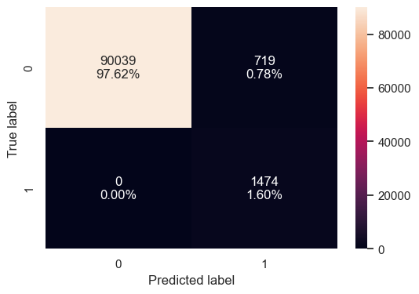

```
Tuned ANN - Training Performance
2883/2883 ━━━━━━━━━━━━━━━━━━━━ 1s 182us/step
```

|  | Accuracy | Recall | Precision | F1 |
| --- | --- | --- | --- | --- |
| 0 | 0.992204 | 1.0 | 0.672139 | 0.803927 |

```
Tuned ANN - Validation Confusion Matrix
618/618 ━━━━━━━━━━━━━━━━━━━━ 0s 195us/step
```

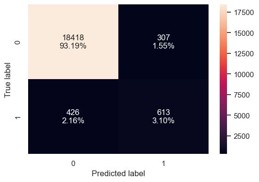

```
Tuned ANN - Validation Performance
618/618 ━━━━━━━━━━━━━━━━━━━━ 0s 260us/step
```

|  | Accuracy | Recall | Precision | F1 |
| --- | --- | --- | --- | --- |
| 0 | 0.962912 | 0.58999 | 0.666304 | 0.62583 |

```
Compare training and validation performance
```

|  |  | Accuracy | Recall | Precision | F1 |
| --- | --- | --- | --- | --- | --- |
| Training | 0 | 0.992204 | 1.00000 | 0.672139 | 0.803927 |
| Validation | 0 | 0.962912 | 0.58999 | 0.666304 | 0.625830 |

```
Compare baseline ANN and tuned ANN validation metrics
```

|  | Model | Accuracy | Recall | Precision | F1 |
| --- | --- | --- | --- | --- | --- |
| 0 | Baseline ANN | 0.959472 | 0.431184 | 0.680851 | 0.527991 |
| 1 | Tuned ANN | 0.962912 | 0.589990 | 0.666304 | 0.625830 |

```python
# Training-set evaluation
print("Tuned ANN - Training Confusion Matrix")
plot_confusion_matrix(tuned_ann_model, X_train_nn, y_train)

print("Tuned ANN - Training Performance")
tuned_ann_train_perf = model_performance_classification(
    tuned_ann_model,
    X_train_nn,
    y_train
)
display(tuned_ann_train_perf)

# Validation-set evaluation
print("Tuned ANN - Validation Confusion Matrix")
plot_confusion_matrix(tuned_ann_model, X_valid_nn, y_valid)

print("Tuned ANN - Validation Performance")
tuned_ann_valid_perf = model_performance_classification(
    tuned_ann_model,
    X_valid_nn,
    y_valid
)
display(tuned_ann_valid_perf)

# Compare training and validation performance.
print("Compare training and validation performance")
tuned_ann_comparison = pd.concat(
    [tuned_ann_train_perf, tuned_ann_valid_perf],
    keys=["Training", "Validation"]
)

display(tuned_ann_comparison)

# Compare baseline ANN and tuned ANN validation metrics.
print("Compare baseline ANN and tuned ANN validation metrics")
ann_validation_comparison = pd.concat(
    [
        ann_valid_perf.assign(Model="Baseline ANN"),
        tuned_ann_valid_perf.assign(Model="Tuned ANN")
    ],
    ignore_index=True
)

display(
    ann_validation_comparison[
        ["Model", "Accuracy", "Recall", "Precision", "F1"]
    ]
)
```

**Observations**

- The tuned ANN improves validation recall by 15.88 percentage points and F1-score by 9.78 percentage points.
- It identifies about 613 of 1,039 failures and misses about 426. This is a clear improvement over the baseline ANN.
- Precision falls only slightly (from 68.09% to 66.63%), so the improved failure detection comes with a modest increase in false alerts.
- Training metrics remain stronger than validation metrics: training F1 is 80.39%, versus validation F1 of 62.58%. This indicates some remaining overfitting, but the Batch Normalization and Dropout architecture provides better validation generalization than the baseline.
- The tuned ANN is a strong improvement over the baseline ANN. However, tuned XGBoost remains the better overall model so far, with higher validation recall (73.24%) and F1-score (69.78%)